# IBI5086 – Lista 2 (1º Sem/2026)

Grupo 4: Amanda Gonçalves, Carlos Lima, Daniel Nogueira, Guilherme Zonzin, Lucas Ito, Victoria Mel

2026-05-18

# 1 Mapeamento de Genes: ANOVA com SNPs

> Gerar X (binomial) e Y (normal); ajustar modelos de ANOVA.

## 1.1 Caso 1 – ANOVA 1 fator em 3 níveis (efeitos aditivo e de dominância)

```r
set.seed(8732)
n_por_genot <- 100

# X: genótipos 0=aa, 1=Aa, 2=AA (distribuição ~binomial(2, p=0.3))
# probabilidades Hardy-Weinberg com p=0.3
p <- 0.3
freq <- c((1-p)^2, 2*p*(1-p), p^2)   # aa, Aa, AA
snp <- sample(0:2, n_por_genot*3, replace=TRUE, prob=freq)

# Y: resposta com efeito aditivo (a=10) e dominância (d=5) sobre a média basal 100
 # mu_aa=100, mu_Aa=115 (=100+d, com d=5 sobre midponto), mu_AA=120 (=100+2a)
# Parametrização: a=(mu_AA-mu_aa)/2=10; d=mu_Aa-(mu_AA+mu_aa)/2=5
mu <- c(100, 115, 120)[snp + 1]
Y1 <- rnorm(length(snp), mean = mu, sd = 5)

dat1 <- data.frame(Y = Y1, SNP = factor(snp, labels = c("aa","Aa","AA")),
                   snp_num = snp)

# Estatísticas descritivas por genótipo
library(psych)
descr1 <- describeBy(dat1, group = "SNP", mat = TRUE)

tabela1 <- descr1[c("Y1", "Y2", "Y3"), c("group1","n","mean","sd","median","min","max")]
tabela1$group1 <- c("aa", "Aa", "AA")
rownames(tabela1) <- NULL

knitr::kable(tabela1, digits = 2,
             col.names = c("genotype","n","mean","sd","median","min","max"),
             caption = "Estatísticas descritivas de Y por genótipo (Caso 1)")
```

Estatísticas descritivas de Y por genótipo (Caso 1)

| genotype | n | mean | sd | median | min | max |
| --- | --- | --- | --- | --- | --- | --- |
| aa | 148 | 100.16 | 5.08 | 100.43 | 85.72 | 111.76 |
| Aa | 123 | 114.57 | 4.94 | 114.23 | 102.09 | 130.30 |
| AA | 29 | 120.15 | 4.63 | 120.39 | 109.25 | 128.01 |

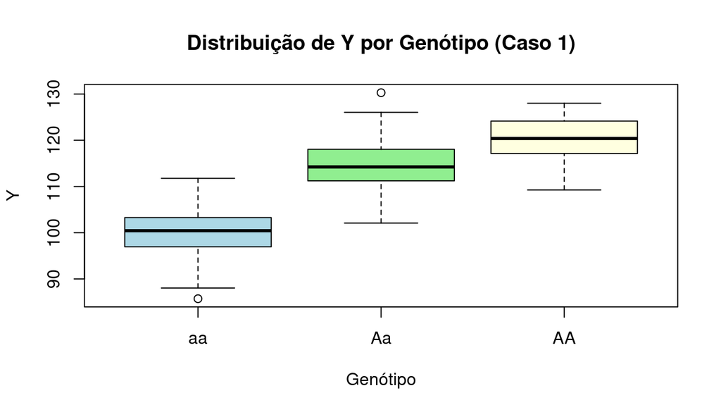

```r
boxplot(Y ~ SNP, data = dat1, col = c("lightblue","lightgreen","lightyellow"),
        main = "Distribuição de Y por Genótipo (Caso 1)", xlab = "Genótipo", ylab = "Y")
```

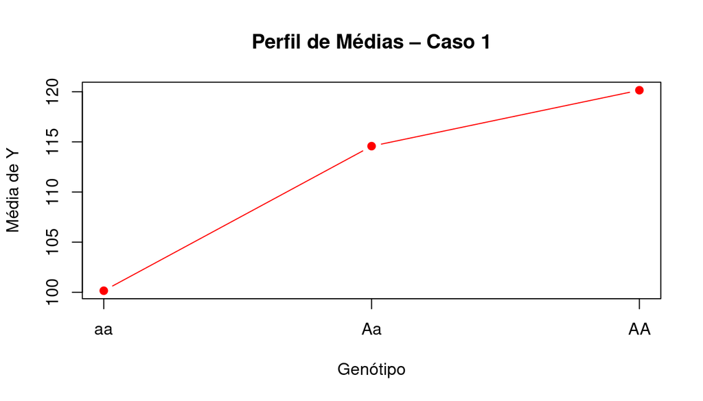

```r
# Perfil de médias
medias1 <- tapply(dat1$Y, dat1$SNP, mean)
plot(0:2, medias1, type = "b", pch = 19, col = "red",
     xaxt = "n", xlab = "Genótipo", ylab = "Média de Y",
     main = "Perfil de Médias – Caso 1")
axis(1, at = 0:2, labels = c("aa","Aa","AA"))
```

### 1.1.1 Codificação dos efeitos aditivo (xa) e de dominância (xd)

```r
# xa: -1 (aa), 0 (Aa), 1 (AA)  → captura efeito aditivo
# xd:  0 (aa), 1 (Aa), 0 (AA)  → captura desvio de dominância
dat1$xa <- dat1$snp_num - 1
dat1$xd <- ifelse(dat1$snp_num == 1, 1, 0)
```

### 1.1.2 Modelo com 2 g.l. – fatores aditivo e de dominância

```r
fit1_ad <- lm(Y ~ xa + xd, data = dat1)
summary(fit1_ad)
```

```
##
## Call:
## lm(formula = Y ~ xa + xd, data = dat1)
##
## Residuals:
##      Min       1Q   Median       3Q      Max
## -14.4366  -3.3116  -0.0913   3.2016  15.7234
##
## Coefficients:
##             Estimate Std. Error t value Pr(>|t|)
## (Intercept) 110.1521     0.5061 217.649  < 2e-16 ***
## xa            9.9967     0.5061  19.752  < 2e-16 ***
## xd            4.4209     0.6768   6.532 2.82e-10 ***
## ---
## Signif. codes:  0 '***' 0.001 '**' 0.01 '*' 0.05 '.' 0.1 ' ' 1
##
## Residual standard error: 4.984 on 297 degrees of freedom
## Multiple R-squared:  0.7171, Adjusted R-squared:  0.7152
## F-statistic: 376.4 on 2 and 297 DF,  p-value: < 2.2e-16
```

```r
anova(fit1_ad)
```

```
## Analysis of Variance Table
##
## Response: Y
##            Df  Sum Sq Mean Sq F value    Pr(>F)
## xa          1 17642.1 17642.1 710.116 < 2.2e-16 ***
## xd          1  1059.9  1059.9  42.663 2.817e-10 ***
## Residuals 297  7378.6    24.8
## ---
## Signif. codes:  0 '***' 0.001 '**' 0.01 '*' 0.05 '.' 0.1 ' ' 1
```

> **Discussão: Interpretação dos coeficientes**

> O intercepto estimado ($\hat{\mu} = 110,15$) representa o ponto médio entre as médias dos homozigotos, $(\mu_{AA} + \mu_{aa})/2$.

> O efeito aditivo (`xa`, $\hat{a} = 9,99$) é altamente significativo ($p < 0,001$), indicando que cada alelo A adicional eleva Y em aproximadamente 10 unidades.

> O efeito de dominância (`xd`, $\hat{d} = 4,42$) é significativo ($p < 0,001$) e positivo, indicando que o heterozigoto acrescenta em torno de 4,42 unidades à média de Y.

> O modelo explica cerca de 72% da variância total de Y (R² = 0,717).

### 1.1.3 Diagnóstico dos resíduos (Caso 1)

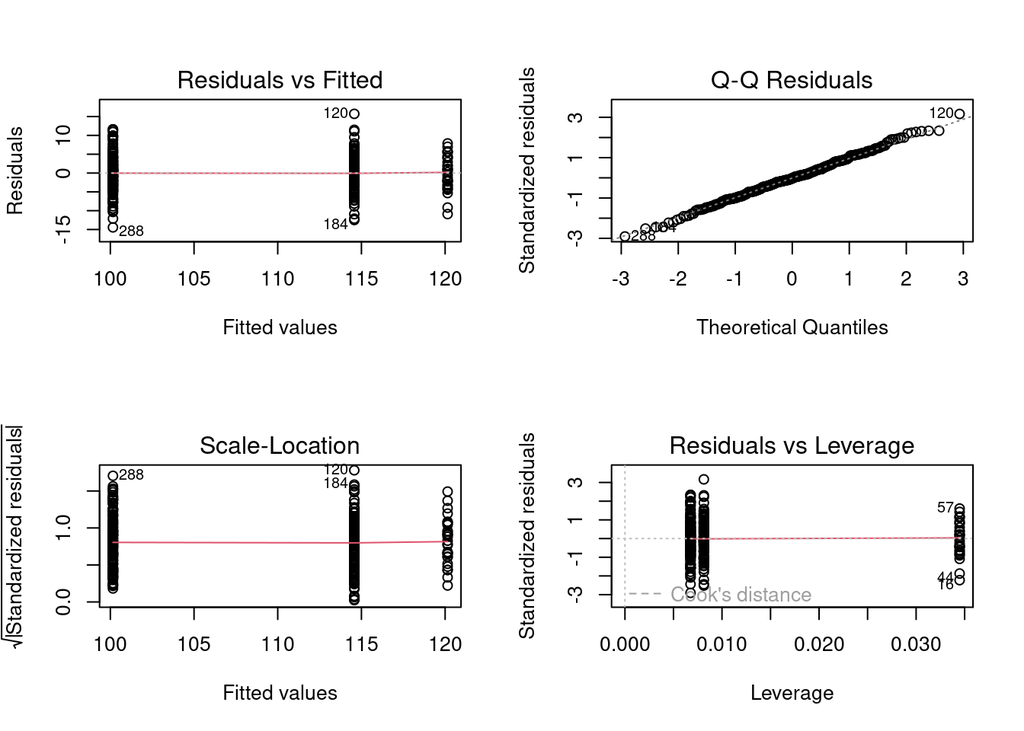

```r
par(mfrow = c(2,2))
plot(fit1_ad)
```

```r
par(mfrow = c(1,1))

shapiro.test(fit1_ad$residuals)
```

```
##
##  Shapiro-Wilk normality test
##
## data:  fit1_ad$residuals
## W = 0.99764, p-value = 0.9466
```

```r
bartlett.test(Y ~ SNP, data = dat1)
```

```
##
##  Bartlett test of homogeneity of variances
##
## data:  Y by SNP
## Bartlett's K-squared = 0.42151, df = 2, p-value = 0.81
```

> **Discussão dos gráficos de diagnóstico**

> Residuals vs Fitted: dispersão vertical nas três colunas parece similar, e a linha vermelha está praticamente horizontal. Aleatoriedade OK.

> Q-Q Residuals: pontos muito bem aderidos à diagonal. Normalidade bem satisfeita.

> Sale-Location: Dispersão bem uniforme, linha vermelha praticamente horizontal, homocedasticidade bem satisfeita. As três observações rotuladas são outliers, nada alarmante.

> Residuals vs Leverage: As observações do genótipo AA concentram-se à direita (~0,033), com maior leverage que os demais genótipos — esperado dado sua menor frequência amostral sob Hardy-Weinberg (p=0,3, ~9% de AA). Ainda assim, a linha de Cook aparece colapsada na borda esquerda do gráfico, indicando que nenhuma observação exerce influência desproporcional sobre os coeficientes. O modelo é estável.

> **Testes de diagnóstico:** O teste de Shapiro-Wilk **não rejeita** a normalidade dos resíduos (W = 0,998; p = 0,947), e o teste de Bartlett **não rejeita** a homogeneidade de variâncias entre os três genótipos (K² = 0,42; gl = 2; p = 0,810). Ambos os resultados confirmam que as suposições do modelo linear são satisfeitas, em concordância com o diagnóstico visual dos gráficos.

### 1.1.4 Comparações múltiplas de Tukey

```r
fit1_aov <- aov(Y ~ SNP, data = dat1)
TukeyHSD(fit1_aov)
```

```
##   Tukey multiple comparisons of means
##     95% family-wise confidence level
##
## Fit: aov(formula = Y ~ SNP, data = dat1)
##
## $SNP
##            diff       lwr       upr p adj
## Aa-aa 14.417637 12.985123 15.850151 0e+00
## AA-aa 19.993374 17.609109 22.377639 0e+00
## AA-Aa  5.575737  3.152098  7.999376 4e-07
```

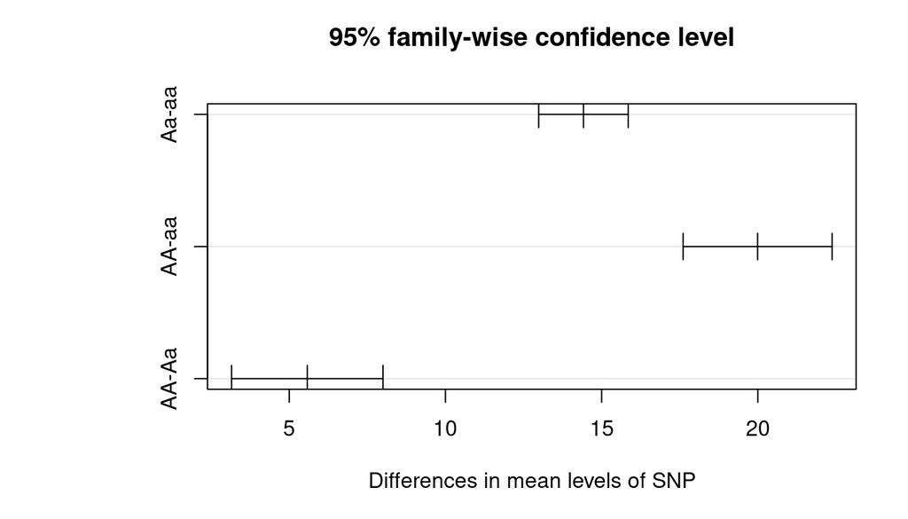

```r
par(mar=c(5,8,4,2))
plot(TukeyHSD(fit1_aov))
```

> **Comparações múltiplas de Tukey:** O teste de Tukey HSD compara os três genótipos par a par com controle da taxa de erro familial a 5%. Aa-aa (diff = 14,42; p < 0,001), AA-aa (diff = 19,99; p < 0,001) e AA-Aa (diff = 5,58; p < 0,001) são todos significativos, confirmando que cada alelo A adicional eleva a média de Y (~10) e que o heterozigoto sofre influência positiva do fator de dominância (~5).

## 1.2 Caso 2 – ANOVA Fatorial 3 $\times$ 3 (dois SNPs, efeitos aditivo, dominância e epistasia)

```r
set.seed(8732)
n_cell <- 100   # por célula (genótipo conjunto)

# SNP1 e SNP2 gerados independentemente (HWE, p1=0.3, p2=0.4)
p1 <- 0.3; p2 <- 0.4
freq1 <- c((1-p1)^2, 2*p1*(1-p1), p1^2)
freq2 <- c((1-p2)^2, 2*p2*(1-p2), p2^2)

snp1 <- sample(0:2, n_cell*9, replace=TRUE, prob=freq1)
snp2 <- sample(0:2, n_cell*9, replace=TRUE, prob=freq2)

# Estrutura de médias com epistasia (interação a1*a2)
# mu_base + a1_efeito + a2_efeito + interacao
a1 <- 8; d1 <- 4; a2 <- 6; d2 <- 3

xa1 <- snp1 - 1        # -1, 0, 1
xd1 <- ifelse(snp1==1, 1, 0) # 0, 1, 0
xa2 <- snp2 - 1
xd2 <- ifelse(snp2==1, 1, 0)

# Modelo com efeitos e interações
mu2 <- 100 + a1*xa1 + d1*xd1 + a2*xa2 + d2*xd2 +
       3*xa1*xa2 + 1.5*xa1*xd2 + 1.5*xd1*xa2 + 1*xd1*xd2

Y2 <- rnorm(length(mu2), mean = mu2, sd = 12)

dat2 <- data.frame(
  Y = Y2,
  SNP1 = factor(snp1, labels = c("a1a1","a1A1","A1A1")),
  SNP2 = factor(snp2, labels = c("a2a2","a2A2","A2A2")),
  xa1 = xa1, xd1 = xd1, xa2 = xa2, xd2 = xd2
)

# Estatísticas descritivas
cat("Dimensões do dataset (Caso 2):", nrow(dat2), "observações\n")
```

```
## Dimensões do dataset (Caso 2): 900 observações
```

```r
tapply(dat2$Y, list(dat2$SNP1, dat2$SNP2), mean) |>
  round(2) |>
  knitr::kable(caption = "Médias de Y por combinação genotípica (Caso 2)")
```

Médias de Y por combinação genotípica (Caso 2)

|  | a2a2 | a2A2 | A2A2 |
| --- | --- | --- | --- |
| a1a1 | 89.06 | 93.35 | 94.94 |
| a1A1 | 97.11 | 109.38 | 113.98 |
| A1A1 | 102.20 | 111.63 | 115.31 |

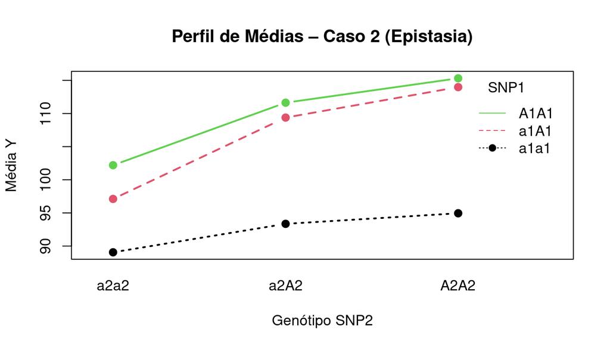

```r
with(dat2,
     interaction.plot(SNP2, SNP1, Y, col = 1:3,
                      main = "Perfil de Médias – Caso 2 (Epistasia)",
                      xlab = "Genótipo SNP2", ylab = "Média Y",
                      lwd = 2, pch = 19, type = "b"))
```

### 1.2.1 Modelo com efeitos aditivos, dominância e interações (8 g.l.)

```r
# Parametrização explícita: xa1, xd1, xa2, xd2 e 4 termos de interação
fit2_completo <- lm(Y ~ xa1 + xd1 + xa2 + xd2 +
                        xa1:xa2 + xa1:xd2 + xd1:xa2 + xd1:xd2,
                    data = dat2)
summary(fit2_completo)
```

```
##
## Call:
## lm(formula = Y ~ xa1 + xd1 + xa2 + xd2 + xa1:xa2 + xa1:xd2 +
##     xd1:xa2 + xd1:xd2, data = dat2)
##
## Residuals:
##     Min      1Q  Median      3Q     Max
## -40.274  -8.232  -0.041   7.851  36.568
##
## Coefficients:
##             Estimate Std. Error t value Pr(>|t|)
## (Intercept) 100.3781     0.9026 111.214  < 2e-16 ***
## xa1           8.3782     0.9026   9.283  < 2e-16 ***
## xd1           5.1671     1.2673   4.077 4.97e-05 ***
## xa2           4.7509     0.9026   5.264 1.77e-07 ***
## xd2           2.1117     1.3771   1.533  0.12552
## xa1:xa2       1.8061     0.9026   2.001  0.04568 *
## xa1:xd2       0.7633     1.3771   0.554  0.57955
## xd1:xa2       3.6857     1.2673   2.908  0.00372 **
## xd1:xd2       1.7276     1.8710   0.923  0.35608
## ---
## Signif. codes:  0 '***' 0.001 '**' 0.01 '*' 0.05 '.' 0.1 ' ' 1
##
## Residual standard error: 11.65 on 891 degrees of freedom
## Multiple R-squared:  0.3604, Adjusted R-squared:  0.3547
## F-statistic: 62.76 on 8 and 891 DF,  p-value: < 2.2e-16
```

```r
anova(fit2_completo)
```

```
## Analysis of Variance Table
##
## Response: Y
##            Df Sum Sq Mean Sq  F value    Pr(>F)
## xa1         1  42983   42983 316.6776 < 2.2e-16 ***
## xd1         1   3509    3509  25.8516 4.495e-07 ***
## xa2         1  16343   16343 120.4054 < 2.2e-16 ***
## xd2         1   1409    1409  10.3809  0.001319 **
## xa1:xa2     1   2194    2194  16.1635 6.302e-05 ***
## xa1:xd2     1    284     284   2.0929  0.148337
## xd1:xa2     1   1313    1313   9.6731  0.001929 **
## xd1:xd2     1    116     116   0.8526  0.356076
## Residuals 891 120937     136
## ---
## Signif. codes:  0 '***' 0.001 '**' 0.01 '*' 0.05 '.' 0.1 ' ' 1
```

> Como houve discrepância entre os resultados da regressão linear e da ANOVA do modelo completo, foi ajustado um modelo reduzido contendo apenas os termos significativos na ANOVA.

```r
fit2_reduzido <- lm(Y ~ xa1 + xd1 + xa2 + xd2 + xa1:xa2 + xd1:xa2, data = dat2)
summary(fit2_reduzido)
```

```
##
## Call:
## lm(formula = Y ~ xa1 + xd1 + xa2 + xd2 + xa1:xa2 + xd1:xa2, data = dat2)
##
## Residuals:
##     Min      1Q  Median      3Q     Max
## -40.681  -8.154  -0.101   8.047  36.959
##
## Coefficients:
##             Estimate Std. Error t value Pr(>|t|)
## (Intercept) 100.1734     0.7717 129.806  < 2e-16 ***
## xa1           8.7385     0.6813  12.826  < 2e-16 ***
## xd1           6.0316     0.9303   6.484 1.48e-10 ***
## xa2           4.6699     0.9007   5.185 2.67e-07 ***
## xd2           2.5019     0.8016   3.121  0.00186 **
## xa1:xa2       1.8991     0.8989   2.113  0.03491 *
## xd1:xa2       4.0195     1.2435   3.233  0.00127 **
## ---
## Signif. codes:  0 '***' 0.001 '**' 0.01 '*' 0.05 '.' 0.1 ' ' 1
##
## Residual standard error: 11.65 on 893 degrees of freedom
## Multiple R-squared:  0.3589, Adjusted R-squared:  0.3546
## F-statistic: 83.31 on 6 and 893 DF,  p-value: < 2.2e-16
```

```r
anova(fit2_reduzido)
```

```
## Analysis of Variance Table
##
## Response: Y
##            Df Sum Sq Mean Sq F value    Pr(>F)
## xa1         1  42983   42983 316.618 < 2.2e-16 ***
## xd1         1   3509    3509  25.847 4.504e-07 ***
## xa2         1  16343   16343 120.383 < 2.2e-16 ***
## xd2         1   1409    1409  10.379  0.001321 **
## xa1:xa2     1   2194    2194  16.160 6.311e-05 ***
## xd1:xa2     1   1419    1419  10.449  0.001272 **
## Residuals 893 121231     136
## ---
## Signif. codes:  0 '***' 0.001 '**' 0.01 '*' 0.05 '.' 0.1 ' ' 1
```

```r
anova(fit2_reduzido,fit2_completo)
```

```
## Analysis of Variance Table
##
## Model 1: Y ~ xa1 + xd1 + xa2 + xd2 + xa1:xa2 + xd1:xa2
## Model 2: Y ~ xa1 + xd1 + xa2 + xd2 + xa1:xa2 + xa1:xd2 + xd1:xa2 + xd1:xd2
##   Res.Df    RSS Df Sum of Sq      F Pr(>F)
## 1    893 121231
## 2    891 120937  2    294.15 1.0836 0.3388
```

> Os modelos foram comparados por ANOVA para modelos aninhados, e como não houve diferença significativa entre eles (p = 0,3388), optou-se pelo modelo reduzido.

> **Interpretação:**  
> - `xa1` e `xa2`: efeitos aditivos dos SNP1 e SNP2, respectivamente.  
> - `xd1` e `xd2`: desvios de dominância de cada SNP.  
> - `xa1:xa2` ($a_1 \times a_2$): **epistasia aditiva $\times$ aditiva** – interação entre os efeitos aditivos.  
> - `xa1:xd2` ($a_1 \times d_2$), `xd1:xa2` ($d_1 \times a_2$): epistasias mistas.  
> - `xd1:xd2` ($d_1 \times d_2$): epistasia dominância $\times$ dominância.

> O modelo explica ~35,9% da variância de Y (R² = 0,359) e é globalmente significativo (F = 83,31; p < 0,001). O erro padrão residual (~11,65) está próximo do valor verdadeiro simulado ($\sigma = 12$), indicando bom ajuste.

> **Efeitos principais:** os efeitos aditivos de ambos os SNPs são significativos — `xa1` ($\hat{a}_1 = 8,74$; p < 0,001) e `xa2` ($\hat{a}_2 = 4,67$; p < 0,001) — indicando que cada alelo A adicional em cada loco eleva Y independentemente. Os efeitos de dominância `xd1` e `xd2` também são significativos pelo summary (p < 0,001 e p < 0,01). Entretanto, como foi detectada epistasia aditiva$\times$aditiva e dominância$\times$aditiva entre os alelos, a interpretação isolada dos efeitos principais pode não ser adequada. Nota: É interessante notar que os coeficientes recuperados para `xa1`, `xa2`, `xd1` e `xd2` foram próximos dos reais usados na geração: (a1 = 8; d1 = 4; a2 = 6; d2 = 3).

> **Epistasia:** as interações aditiva$\times$aditiva `xa1:xa2` e dominância$\times$aditiva `xd1:xa2` são significativas na tabela ANOVA (xa1:xa2 -> F = 16,16; p < 0,001 | xd1:xa2 -> F = 10,45; p < 0,01). As demais interações não atingem significância, embora o valor verdadeiro simulado das interações `xd1:xa2`e `xa1:xd2` fossem idênticos (1.5x). A diferença em significância é reflexo da variação amostral e não um erro.

> Em conjunto, os resultados confirmam que o fenótipo Y é influenciado pelos efeitos aditivos de dois locos e por sua interação epistática, padrão visualmente antecipado pelo não-paralelismo das linhas no perfil de médias.

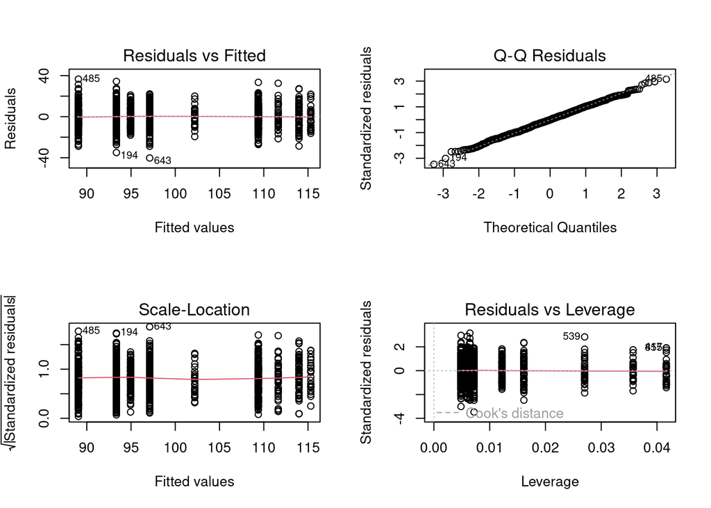

```r
par(mfrow = c(2,2)); plot(fit2_completo); par(mfrow = c(1,1))
```

```r
shapiro.test(fit2_completo$residuals)
```

```
##
##  Shapiro-Wilk normality test
##
## data:  fit2_completo$residuals
## W = 0.99908, p-value = 0.9438
```

> **Diagnóstico dos resíduos – Caso 2:**

> **Residuals vs Fitted:** os pontos distribuem-se em colunas verticais correspondentes às 9 combinações genotípicas (células do fatorial 3$$3), padrão esperado com preditores discretos. A linha vermelha é aproximadamente horizontal em 0, sem curvatura sistemática, indicando que o modelo linear é adequado.

> **Q-Q Residuals:** excelente aderência à diagonal em toda a extensão central, com desvios pequenos nas caudas. A normalidade dos resíduos é confirmada formalmente pelo teste de Shapiro-Wilk (W = 0,999; p = 0,944), que não rejeita $H_0$.

> **Scale-Location:** a linha vermelha é praticamente horizontal e a distribuição dos resíduos aparenta ser uniforme.

> **Residuals vs Leverage:** os pontos se distribuem em faixas de leverage distintas, refletindo as diferentes frequências das 9 células genotípicas — células raras (como A1A1 com p1=0,3) têm maior leverage. Ainda assim, a linha de Cook permanece colapsada na borda inferior do gráfico, indicando que nenhuma observação exerce influência desproporcional sobre os coeficientes.

# 2 Delineamento Fatorial 3 $\times$ 2: SNP $\times$ Subgrupo Populacional

## 2.1 Simulação dos dados (P1, P2, P3) (item a)

```r
set.seed(8732)
n_rep <- 30   # réplicas
sigma  <- 8   # desvio padrão

# Médias fornecidas na lista
medias_pop <- list(
  P1 = matrix(c(80,80,80, 90,90,90), nrow=2, byrow=TRUE,
              dimnames=list(c("A","B"), c("aa","Aa","AA"))),
  P2 = matrix(c(75,80,90, 80,86,97), nrow=2, byrow=TRUE,
              dimnames=list(c("A","B"), c("aa","Aa","AA"))),
  P3 = matrix(c(75,80,85, 75,85,100), nrow=2, byrow=TRUE,
              dimnames=list(c("A","B"), c("aa","Aa","AA")))
)

# Gerar dados para cada população
gerar_pop <- function(mmat, n, sigma, pop_nome) {
  rows <- list()
  for (grp in rownames(mmat)) {
    for (geno in colnames(mmat)) {
      y <- rnorm(n, mean = mmat[grp, geno], sd = sigma)
      rows[[length(rows)+1]] <- data.frame(
        Y = y, Grupo = grp, Genotipo = geno,
        Geno_num = match(geno, c("aa","Aa","AA")) - 1,
        Pop = pop_nome
      )
    }
  }
  do.call(rbind, rows)
}

dat_P1 <- gerar_pop(medias_pop$P1, n_rep, sigma, "P1")
dat_P2 <- gerar_pop(medias_pop$P2, n_rep, sigma, "P2")
dat_P3 <- gerar_pop(medias_pop$P3, n_rep, sigma, "P3")

# Ordenar fatores
dat_P1$Genotipo <- factor(dat_P1$Genotipo, levels=c("aa","Aa","AA"))
dat_P2$Genotipo <- factor(dat_P2$Genotipo, levels=c("aa","Aa","AA"))
dat_P3$Genotipo <- factor(dat_P3$Genotipo, levels=c("aa","Aa","AA"))
```

> **Contextualização (item b):** Os dados representam medições de pressão arterial diastólica em repouso (mmHg) em indivíduos de três populações distintas (P1, P2, P3), classificados segundo o genótipo de um SNP (aa, Aa, AA) e a origem geográfica (A e B). Adotou-se $n = 30$ réplicas por co-ordenada (Grupo $\times$ Genótipo) $\sigma = 8$ mmHg. As três populações representam cenários distintos: **P1** sem efeito do SNP (apenas diferença entre subgrupos: B $\approx$ 10 mmHg acima de A); **P2** com efeito do SNP e perfis paralelos entre subgrupos; e **P3** com interação SNP$\times$subgrupo, onde o efeito do SNP é modesto em A (+10 mmHg de aa→AA) mas acentuado em B (+25 mmHg), sugerindo que fatores populacionais do subgrupo B potencializam o efeito do SNP sobre a pressão diastólica.

## 2.2 Análise por População

### 2.2.1 Função auxiliar para análise completa

```r
analisa_pop <- function(dat, nome_pop) {
  cat("\n\n========================================\n")
  cat(" POPULAÇÃO:", nome_pop, "\n")
  cat("========================================\n\n")

  # (i) Estatísticas descritivas
  cat("--- (i) Estatísticas Descritivas ---\n")
  desc <- describeBy(dat, group = list(dat$Grupo, dat$Genotipo), mat=TRUE)
  print(knitr::kable(desc[grepl("^Y", rownames(desc)),
                      c("group1","group2","n","mean","sd","median")],
                         digits=2, caption=paste("Descritivas –", nome_pop)))

  # (ii) Perfil de médias
  par(mfrow=c(1,2))
  with(dat,
       interaction.plot(Genotipo, Grupo, Y,
                        col=c("red","blue"), lwd=2, pch=19, type="b",
                        main=paste("Perfil de Médias –", nome_pop),
                        xlab="Genótipo SNP", ylab="Média Y"))

  # Boxplot
  boxplot(Y ~ Grupo:Genotipo, data=dat, col=c("lightcoral","lightblue"),
          main=paste("Boxplot –", nome_pop),
          xlab="Grupo:Genótipo", ylab="Y", las=2, cex.axis=0.7)
  par(mfrow=c(1,1))

  # (iii) ANOVA Fatorial 3$\times$2 – fator categórico
  cat("\n--- (iii) ANOVA Fatorial 3x2 (Genotipo categórico) ---\n")
  fit_cat <- aov(Y ~ Grupo * Genotipo, data=dat)
  print(summary(fit_cat))
  cat("\nCoeficientes:\n")
  print(coef(fit_cat))

  # Diagnóstico resíduos
  par(mfrow=c(2,2)); plot(fit_cat); par(mfrow=c(1,1))
  cat("\nShapiro-Wilk (normalidade resíduos):\n")
  print(shapiro.test(fit_cat$residuals))
  cat("Bartlett (homocedasticidade):\n")
  print(bartlett.test(Y ~ interaction(Grupo, Genotipo), data=dat))

  # Tukey
  cat("\nComparações múltiplas de Tukey:\n")
  tk <- TukeyHSD(fit_cat)
  print(tk)
  plot(tk, las=1, cex.axis=0.6)

  # (iv) SNP como variável quantitativa (1 g.l. – efeito linear)
  cat("\n--- (iv) SNP como variável quantitativa (efeito aditivo linear) ---\n")
  fit_num <- lm(Y ~ Grupo * Geno_num, data=dat)
  print(summary(fit_num))
  print(anova(fit_num))

  cat("\nComparação R²: categórico =", round(summary(lm(Y ~ Grupo * Genotipo, data=dat))$r.squared, 3),
    "| quantitativo =", round(summary(fit_num)$r.squared, 3), "\n")

  invisible(list(fit_cat=fit_cat, fit_num=fit_num))
}
```

### 2.2.2 P1 – Sem efeito de SNP, sem interação

```r
res_P1 <- analisa_pop(dat_P1, "P1")
```

```
##
##
## ========================================
##  POPULAÇÃO: P1
## ========================================
##
## --- (i) Estatísticas Descritivas ---
##
##
## Table: Descritivas – P1
##
## |   |group1 |group2 |  n|  mean|   sd| median|
## |:--|:------|:------|--:|-----:|----:|------:|
## |Y1 |A      |aa     | 30| 79.95| 7.92|  79.10|
## |Y2 |B      |aa     | 30| 90.51| 9.23|  90.51|
## |Y3 |A      |Aa     | 30| 78.93| 9.11|  79.71|
## |Y4 |B      |Aa     | 30| 91.34| 6.16|  90.93|
## |Y5 |A      |AA     | 30| 78.98| 5.76|  78.81|
## |Y6 |B      |AA     | 30| 89.59| 7.35|  90.83|
```

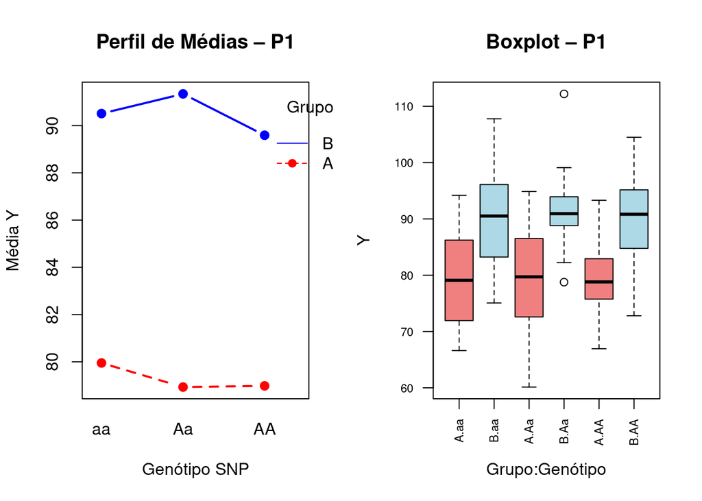

```
##
## --- (iii) ANOVA Fatorial 3x2 (Genotipo categórico) ---
##                 Df Sum Sq Mean Sq F value Pr(>F)
## Grupo            1   5637    5637  94.959 <2e-16 ***
## Genotipo         2     32      16   0.273  0.761
## Grupo:Genotipo   2     33      17   0.281  0.755
## Residuals      174  10328      59
## ---
## Signif. codes:  0 '***' 0.001 '**' 0.01 '*' 0.05 '.' 0.1 ' ' 1
##
## Coeficientes:
##       (Intercept)            GrupoB        GenotipoAa        GenotipoAA GrupoB:GenotipoAa GrupoB:GenotipoAA
##       79.95232024       10.55691612       -1.01984317       -0.96910237        1.85320676        0.05166645
```

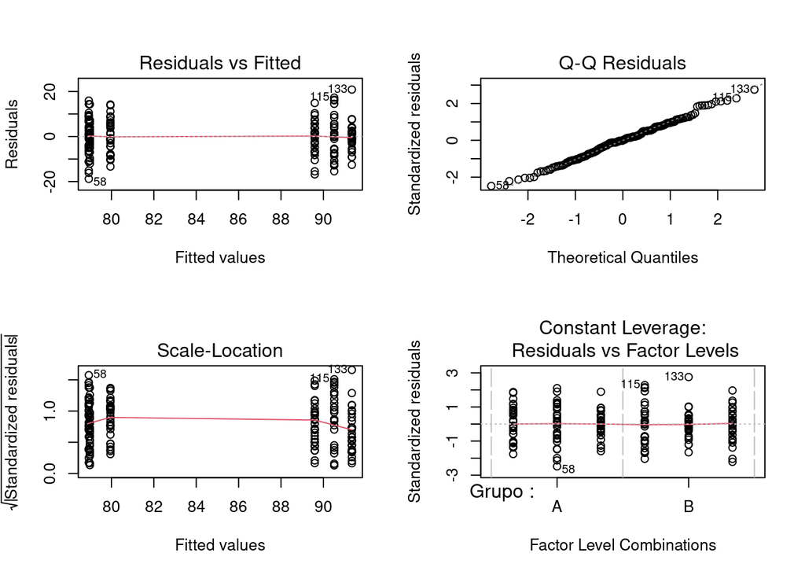

```
##
## Shapiro-Wilk (normalidade resíduos):
##
##  Shapiro-Wilk normality test
##
## data:  fit_cat$residuals
## W = 0.99448, p-value = 0.7439
##
## Bartlett (homocedasticidade):
##
##  Bartlett test of homogeneity of variances
##
## data:  Y by interaction(Grupo, Genotipo)
## Bartlett's K-squared = 10.56, df = 5, p-value = 0.06083
##
##
## Comparações múltiplas de Tukey:
##   Tukey multiple comparisons of means
##     95% family-wise confidence level
##
## Fit: aov(formula = Y ~ Grupo * Genotipo, data = dat)
##
## $Grupo
##         diff      lwr      upr p adj
## B-A 11.19187 8.925067 13.45868     0
##
## $Genotipo
##              diff       lwr      upr     p adj
## Aa-aa -0.09323979 -3.418441 3.231961 0.9975806
## AA-aa -0.94326914 -4.268470 2.381932 0.7808776
## AA-Aa -0.85002935 -4.175230 2.475172 0.8179569
##
## $`Grupo:Genotipo`
##                   diff        lwr       upr     p adj
## B:aa-A:aa  10.55691612   4.824323 16.289509 0.0000050
## A:Aa-A:aa  -1.01984317  -6.752436  4.712750 0.9956337
## B:Aa-A:aa  11.39027971   5.657687 17.122873 0.0000007
## A:AA-A:aa  -0.96910237  -6.701695  4.763490 0.9965684
## B:AA-A:aa   9.63948021   3.906887 15.372073 0.0000406
## A:Aa-B:aa -11.57675930 -17.309352 -5.844166 0.0000004
## B:Aa-B:aa   0.83336358  -4.899229  6.565956 0.9983292
## A:AA-B:aa -11.52601849 -17.258611 -5.793426 0.0000005
## B:AA-B:aa  -0.91743592  -6.650029  4.815157 0.9973543
## B:Aa-A:Aa  12.41012288   6.677530 18.142716 0.0000000
## A:AA-A:Aa   0.05074081  -5.681852  5.783334 1.0000000
## B:AA-A:Aa  10.65932338   4.926731 16.391916 0.0000039
## A:AA-B:Aa -12.35938207 -18.091975 -6.626789 0.0000001
## B:AA-B:Aa  -1.75079950  -7.483392  3.981793 0.9508273
## B:AA-A:AA  10.60858257   4.875990 16.341175 0.0000044
```

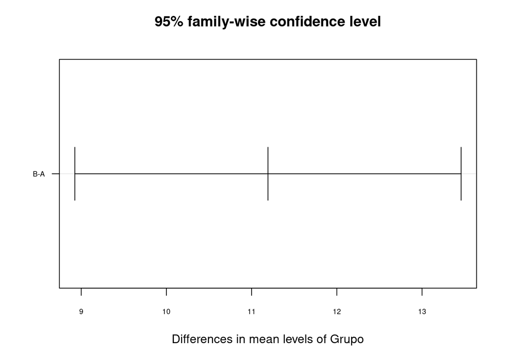

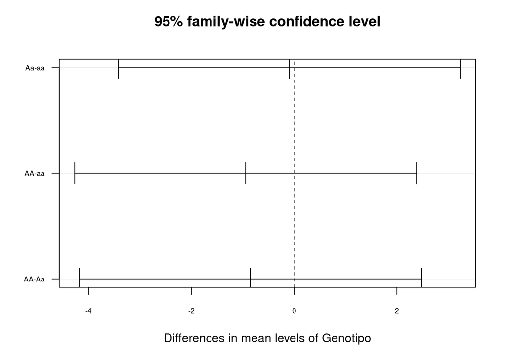

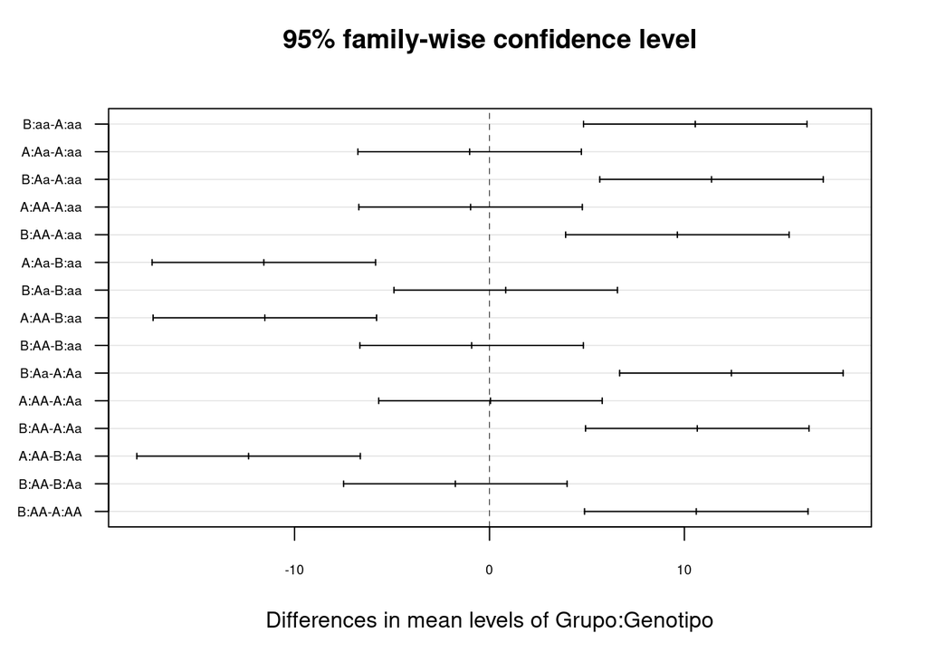

```
##
## --- (iv) SNP como variável quantitativa (efeito aditivo linear) ---
##
## Call:
## lm(formula = Y ~ Grupo * Geno_num, data = dat)
##
## Residuals:
##      Min       1Q   Median       3Q      Max
## -19.1528  -5.2945   0.0742   5.0879  21.7213
##
## Coefficients:
##                 Estimate Std. Error t value Pr(>|t|)
## (Intercept)     79.77389    1.27917  62.364  < 2e-16 ***
## GrupoB          11.16604    1.80902   6.172 4.51e-09 ***
## Geno_num        -0.48455    0.99084  -0.489    0.625
## GrupoB:Geno_num  0.02583    1.40126   0.018    0.985
## ---
## Signif. codes:  0 '***' 0.001 '**' 0.01 '*' 0.05 '.' 0.1 ' ' 1
##
## Residual standard error: 7.675 on 176 degrees of freedom
## Multiple R-squared:  0.3533, Adjusted R-squared:  0.3423
## F-statistic: 32.05 on 3 and 176 DF,  p-value: < 2.2e-16
##
## Analysis of Variance Table
##
## Response: Y
##                 Df  Sum Sq Mean Sq F value Pr(>F)
## Grupo            1  5636.6  5636.6 95.6879 <2e-16 ***
## Geno_num         1    26.7    26.7  0.4531 0.5017
## Grupo:Geno_num   1     0.0     0.0  0.0003 0.9853
## Residuals      176 10367.5    58.9
## ---
## Signif. codes:  0 '***' 0.001 '**' 0.01 '*' 0.05 '.' 0.1 ' ' 1
##
## Comparação R²: categórico = 0.356 | quantitativo = 0.353
```

> **Interpretação P1:**

> **Perfil de médias e boxplot:** as linhas do perfil de médias oscilam levemente entre genótipos — a linha do subgrupo B sobe de aa para Aa e recua em AA, enquanto a do subgrupo A desce ligeiramente — mas essas variações refletem apenas flutuação amostral, hipótese fortalecida pelos testes seguintes. A separação vertical entre subgrupos é consistente e visualmente dominante. O boxplot corrobora: as distribuições dentro de cada subgrupo são similares entre genótipos.

> **ANOVA:** apenas o efeito de Grupo é significativo (F = 94,96; p < 0,001). Os efeitos de Genótipo (F = 0,27; p = 0,761) e da interação Grupo$\times$Genótipo (F = 0,28; p = 0,755) não são significativos.

> **Diagnóstico:** normalidade (Shapiro-Wilk: W = 0,994; p = 0,744) e homocedasticidade (Bartlett: K² = 10,56; p = 0,061) satisfeitas. O gráfico “Constant Leverage” mostra resíduos uniformemente distribuídos entre os níveis de Grupo, sem padrões preocupantes.

> **Tukey:** o contraste B-A é significativo (~11,2 mmHg; p < 0,001). Todos os contrastes entre genótipos (Aa-aa, AA-aa, AA-Aa) incluem o zero nos ICs e têm p > 0,75, confirmando ausência de efeito do SNP sobre a pressão diastólica. No Tukey da interação Grupo:Genótipo, os únicos contrastes significativos são aqueles que comparam subgrupos opostos (ex.: B:aa-A:aa, B:Aa-A:Aa), confirmando que toda a significância se deve ao efeito de subgrupo, não ao SNP.

> **SNP quantitativo (item iv):** o modelo com `Geno_num` confirma: coeficiente do SNP não significativo (-0,48; p = 0,625) e interação Grupo$\times$Geno_num também não significativa (p = 0,985). O ajuste é praticamente equivalente ao modelo categórico (R² = categórico 0.356 | quantitativo 0.353), com a variância explicada quase integralmente pelo efeito de subgrupo populacional.

### 2.2.3 P2 – Efeito aditivo de SNP, sem interação (perfis paralelos)

```r
res_P2 <- analisa_pop(dat_P2, "P2")
```

```
##
##
## ========================================
##  POPULAÇÃO: P2
## ========================================
##
## --- (i) Estatísticas Descritivas ---
##
##
## Table: Descritivas – P2
##
## |   |group1 |group2 |  n|  mean|   sd| median|
## |:--|:------|:------|--:|-----:|----:|------:|
## |Y1 |A      |aa     | 30| 74.03| 9.13|  74.11|
## |Y2 |B      |aa     | 30| 79.11| 7.25|  78.43|
## |Y3 |A      |Aa     | 30| 79.76| 8.37|  79.23|
## |Y4 |B      |Aa     | 30| 84.61| 7.90|  83.63|
## |Y5 |A      |AA     | 30| 90.08| 7.68|  89.23|
## |Y6 |B      |AA     | 30| 98.91| 8.27| 101.49|
```

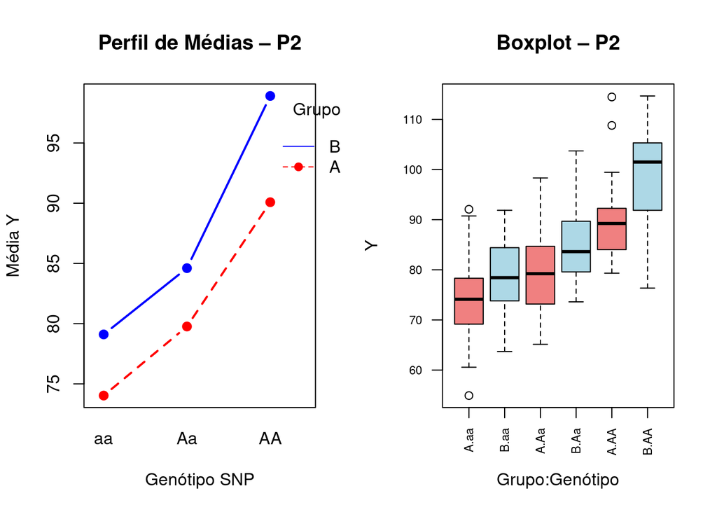

```
##
## --- (iii) ANOVA Fatorial 3x2 (Genotipo categórico) ---
##                 Df Sum Sq Mean Sq F value   Pr(>F)
## Grupo            1   1757    1757  26.627 6.68e-07 ***
## Genotipo         2  10091    5046  76.474  < 2e-16 ***
## Grupo:Genotipo   2    150      75   1.134    0.324
## Residuals      174  11480      66
## ---
## Signif. codes:  0 '***' 0.001 '**' 0.01 '*' 0.05 '.' 0.1 ' ' 1
##
## Coeficientes:
##       (Intercept)            GrupoB        GenotipoAa        GenotipoAA GrupoB:GenotipoAa GrupoB:GenotipoAA
##        74.0288813         5.0763575         5.7354973        16.0553098        -0.2321264         3.7477700
```

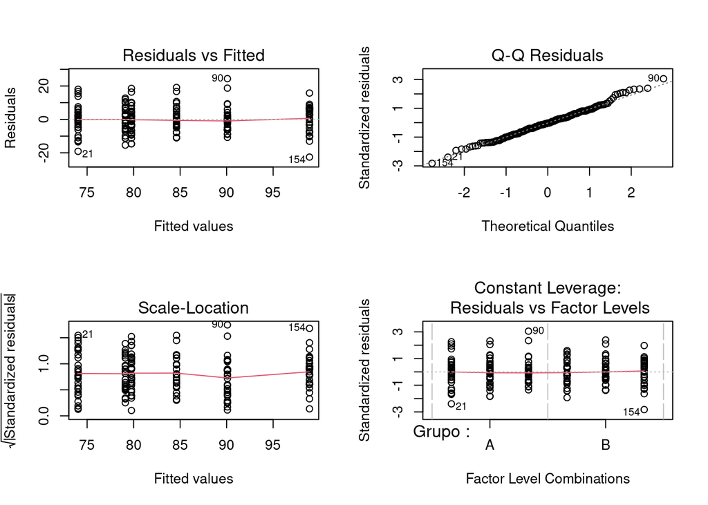

```
##
## Shapiro-Wilk (normalidade resíduos):
##
##  Shapiro-Wilk normality test
##
## data:  fit_cat$residuals
## W = 0.9929, p-value = 0.5306
##
## Bartlett (homocedasticidade):
##
##  Bartlett test of homogeneity of variances
##
## data:  Y by interaction(Grupo, Genotipo)
## Bartlett's K-squared = 1.8307, df = 5, p-value = 0.872
##
##
## Comparações múltiplas de Tukey:
##   Tukey multiple comparisons of means
##     95% family-wise confidence level
##
## Fit: aov(formula = Y ~ Grupo * Genotipo, data = dat)
##
## $Grupo
##         diff     lwr      upr p adj
## B-A 6.248239 3.85837 8.638107 7e-07
##
## $Genotipo
##            diff       lwr       upr     p adj
## Aa-aa  5.619434  2.113712  9.125156 0.0006069
## AA-aa 17.929195 14.423473 21.434916 0.0000000
## AA-Aa 12.309761  8.804039 15.815482 0.0000000
##
## $`Grupo:Genotipo`
##                 diff        lwr       upr     p adj
## B:aa-A:aa  5.0763575 -0.9674497 11.120165 0.1549331
## A:Aa-A:aa  5.7354973 -0.3083098 11.779304 0.0736213
## B:Aa-A:aa 10.5797283  4.5359212 16.623535 0.0000167
## A:AA-A:aa 16.0553098 10.0115027 22.099117 0.0000000
## B:AA-A:aa 24.8794373 18.8356302 30.923244 0.0000000
## A:Aa-B:aa  0.6591398 -5.3846673  6.702947 0.9995854
## B:Aa-B:aa  5.5033709 -0.5404363 11.547178 0.0969478
## A:AA-B:aa 10.9789523  4.9351452 17.022759 0.0000070
## B:AA-B:aa 19.8030798 13.7592727 25.846887 0.0000000
## B:Aa-A:Aa  4.8442311 -1.1995761 10.888038 0.1957295
## A:AA-A:Aa 10.3198125  4.2760054 16.363620 0.0000291
## B:AA-A:Aa 19.1439400 13.1001329 25.187747 0.0000000
## A:AA-B:Aa  5.4755815 -0.5682257 11.519389 0.1001007
## B:AA-B:Aa 14.2997090  8.2559018 20.343516 0.0000000
## B:AA-A:AA  8.8241275  2.7803204 14.867935 0.0005826
```

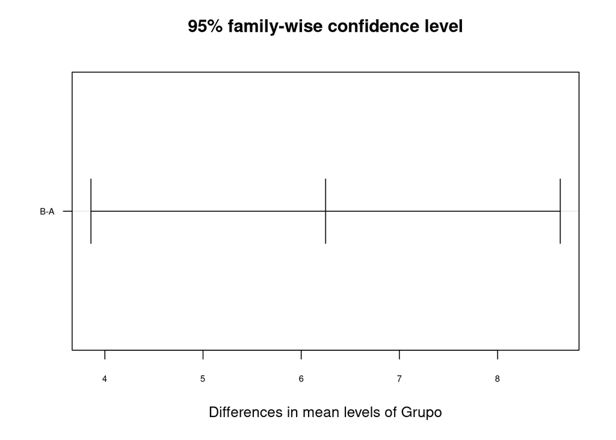

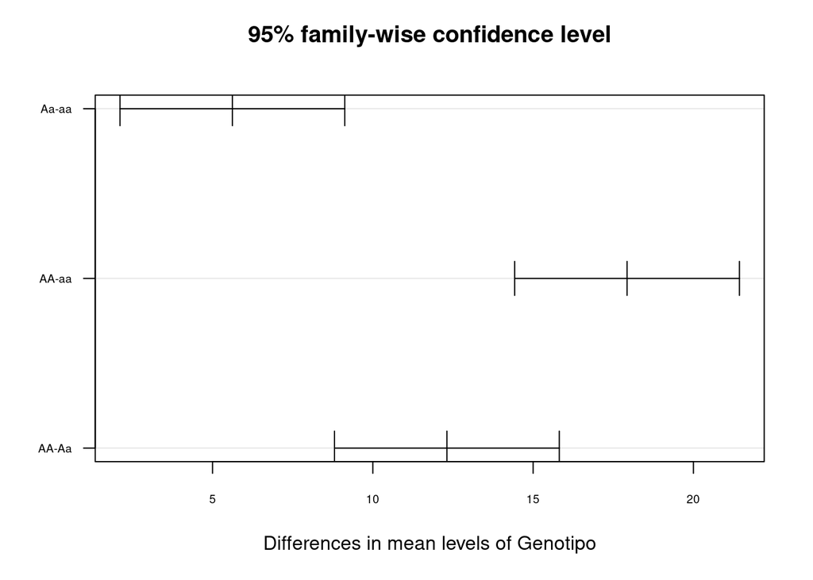

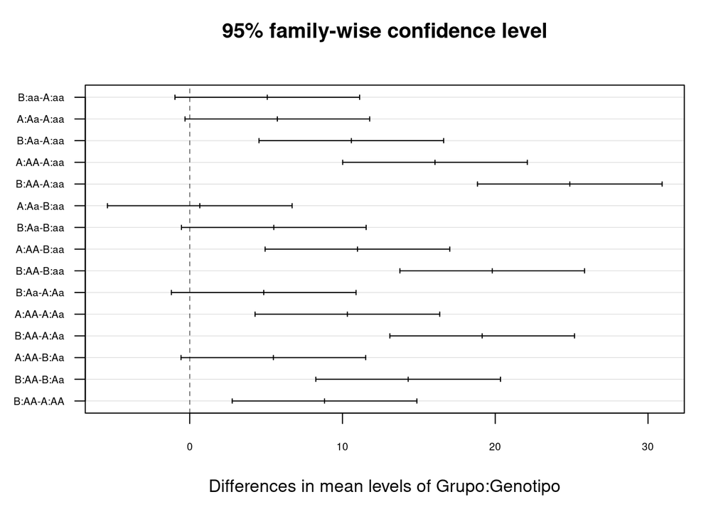

```
##
## --- (iv) SNP como variável quantitativa (efeito aditivo linear) ---
##
## Call:
## lm(formula = Y ~ Grupo * Geno_num, data = dat)
##
## Residuals:
##      Min       1Q   Median       3Q      Max
## -21.0974  -5.5636   0.1684   4.8664  25.1543
##
## Coefficients:
##                 Estimate Std. Error t value Pr(>|t|)
## (Intercept)       73.265      1.375  53.299  < 2e-16 ***
## GrupoB             4.374      1.944   2.250   0.0257 *
## Geno_num           8.028      1.065   7.539 2.41e-12 ***
## GrupoB:Geno_num    1.874      1.506   1.244   0.2150
## ---
## Signif. codes:  0 '***' 0.001 '**' 0.01 '*' 0.05 '.' 0.1 ' ' 1
##
## Residual standard error: 8.248 on 176 degrees of freedom
## Multiple R-squared:  0.4901, Adjusted R-squared:  0.4814
## F-statistic: 56.38 on 3 and 176 DF,  p-value: < 2.2e-16
##
## Analysis of Variance Table
##
## Response: Y
##                 Df  Sum Sq Mean Sq  F value    Pr(>F)
## Grupo            1  1756.8  1756.8  25.8265 9.479e-07 ***
## Geno_num         1  9643.7  9643.7 141.7691 < 2.2e-16 ***
## Grupo:Geno_num   1   105.3   105.3   1.5486     0.215
## Residuals      176 11972.2    68.0
## ---
## Signif. codes:  0 '***' 0.001 '**' 0.01 '*' 0.05 '.' 0.1 ' ' 1
##
## Comparação R²: categórico = 0.511 | quantitativo = 0.49
```

> **Interpretação P2:**

> **Perfil de médias e boxplot:** as linhas do perfil de médias variam de forma ascendente entre os genótipos. As linhas dos subgrupos são aproximadamente paralelas, indicando independência do efeito do SNP em relação ao subgrupo. O boxplot corrobora: as distribuições dentro de cada subgrupo mostram aumento progressivo da mediana e da média de Y de aa para AA.

> **ANOVA:** são significativos tanto o efeito de Grupo(F = 26,63; p < 0,001) quanto do Genótipo (F = 76,47; p < 0,001). Já interação Grupo$\times$Genótipo é não significativa (F = 1,134; p = 0,324).

> **Diagnóstico:** normalidade (Shapiro-Wilk: W = 0,993; p = 0,531) e homocedasticidade (Bartlett: K² = 1,831; p = 0,872) satisfeitas. O gráfico “Constant Leverage” mostra resíduos bem distribuídos.

> **Tukey:** o contraste B-A é significativo (~6,2 mmHg; p < 0,001), indicando diferença entre subgrupos. Todos os contrastes entre genótipos são significativos (Aa-aa: +5,6 mmHg, p < 0,001; AA-aa: +17,9 mmHg, p < 0,001; AA-Aa: +12,3 mmHg, p < 0,001), confirmando o efeito do SNP sobre a pressão diastólica. No Tukey da interação Grupo:Genótipo, os contrastes dentro do mesmo subgrupo entre genótipos distintos são em sua maioria significativos (ex.: A:AA-A:aa, B:AA-B:aa), enquanto contrastes entre subgrupos dentro do mesmo genótipo tendem a não atingir significância isoladamente (ex.: B:aa-A:aa: p = 0,155; B:Aa-A:Aa: p = 0,196), sugerindo que o efeito de subgrupo é menos pronunciado do que o efeito do SNP nesta população. A ausência de interação significativa na ANOVA é corroborada: o padrão de diferenças entre genótipos é consistente entre os subgrupos A e B.

### 2.2.4 P3 – Efeito de SNP com interação (epistasia SNP $\times$ Subgrupo)

```r
res_P3 <- analisa_pop(dat_P3, "P3")
```

```
##
##
## ========================================
##  POPULAÇÃO: P3
## ========================================
##
## --- (i) Estatísticas Descritivas ---
##
##
## Table: Descritivas – P3
##
## |   |group1 |group2 |  n|   mean|   sd| median|
## |:--|:------|:------|--:|------:|----:|------:|
## |Y1 |A      |aa     | 30|  76.23| 7.10|  75.47|
## |Y2 |B      |aa     | 30|  75.40| 8.69|  74.82|
## |Y3 |A      |Aa     | 30|  78.91| 7.77|  78.46|
## |Y4 |B      |Aa     | 30|  84.26| 7.96|  84.10|
## |Y5 |A      |AA     | 30|  85.42| 9.07|  84.44|
## |Y6 |B      |AA     | 30| 100.44| 9.68| 101.09|
```

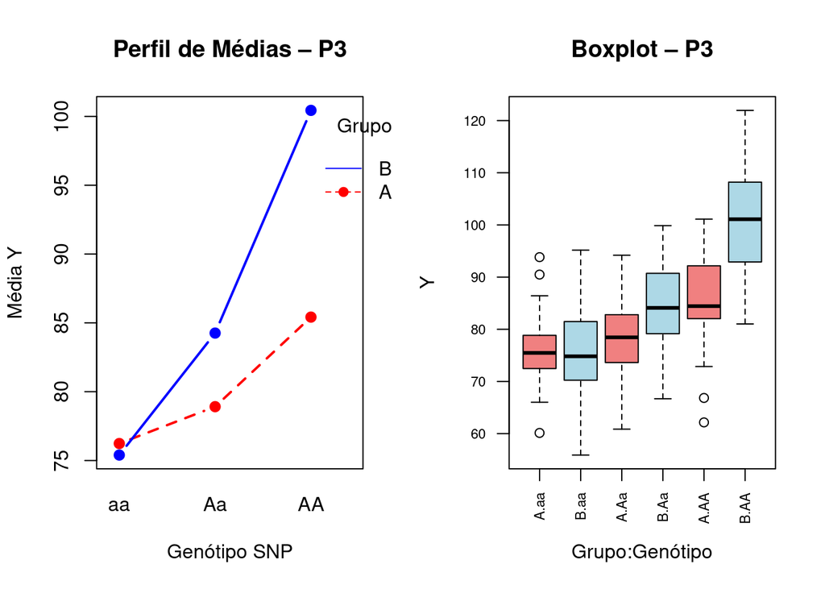

```
##
## --- (iii) ANOVA Fatorial 3x2 (Genotipo categórico) ---
##                 Df Sum Sq Mean Sq F value   Pr(>F)
## Grupo            1   1906    1906   26.87 5.99e-07 ***
## Genotipo         2   9096    4548   64.10  < 2e-16 ***
## Grupo:Genotipo   2   1916     958   13.50 3.54e-06 ***
## Residuals      174  12345      71
## ---
## Signif. codes:  0 '***' 0.001 '**' 0.01 '*' 0.05 '.' 0.1 ' ' 1
##
## Coeficientes:
##       (Intercept)            GrupoB        GenotipoAa        GenotipoAA GrupoB:GenotipoAa GrupoB:GenotipoAA
##        76.2341934        -0.8376434         2.6775862         9.1847370         6.1835631        15.8557776
```

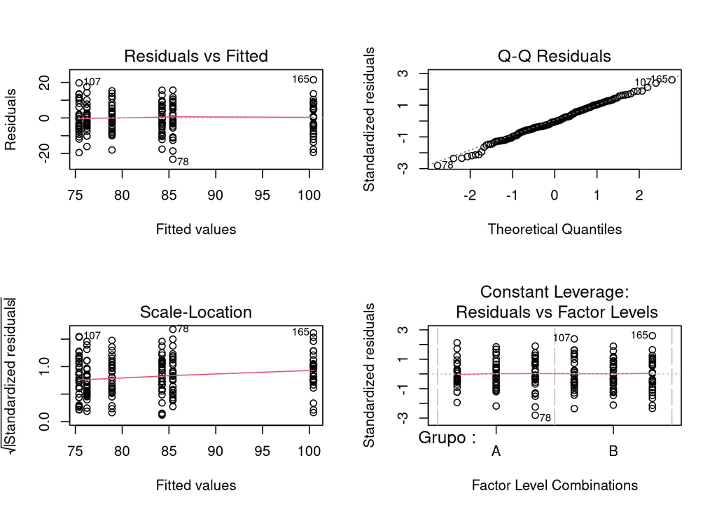

```
##
## Shapiro-Wilk (normalidade resíduos):
##
##  Shapiro-Wilk normality test
##
## data:  fit_cat$residuals
## W = 0.99501, p-value = 0.8113
##
## Bartlett (homocedasticidade):
##
##  Bartlett test of homogeneity of variances
##
## data:  Y by interaction(Grupo, Genotipo)
## Bartlett's K-squared = 3.6449, df = 5, p-value = 0.6016
##
##
## Comparações múltiplas de Tukey:
##   Tukey multiple comparisons of means
##     95% family-wise confidence level
##
## Fit: aov(formula = Y ~ Grupo * Genotipo, data = dat)
##
## $Grupo
##         diff      lwr      upr p adj
## B-A 6.508804 4.030576 8.987031 6e-07
##
## $Genotipo
##            diff       lwr       upr     p adj
## Aa-aa  5.769368  2.134031  9.404705 0.0006967
## AA-aa 17.112626 13.477289 20.747963 0.0000000
## AA-Aa 11.343258  7.707921 14.978595 0.0000000
##
## $`Grupo:Genotipo`
##                 diff        lwr       upr     p adj
## B:aa-A:aa -0.8376434 -7.1049053  5.429619 0.9988855
## A:Aa-A:aa  2.6775862 -3.5896757  8.944848 0.8210097
## B:Aa-A:aa  8.0235058  1.7562439 14.290768 0.0040153
## A:AA-A:aa  9.1847370  2.9174751 15.451999 0.0005474
## B:AA-A:aa 24.2028712 17.9356094 30.470133 0.0000000
## A:Aa-B:aa  3.5152295 -2.7520324  9.782491 0.5889066
## B:Aa-B:aa  8.8611492  2.5938873 15.128411 0.0009766
## A:AA-B:aa 10.0223804  3.7551185 16.289642 0.0001131
## B:AA-B:aa 25.0405146 18.7732527 31.307777 0.0000000
## B:Aa-A:Aa  5.3459197 -0.9213422 11.613182 0.1426013
## A:AA-A:Aa  6.5071509  0.2398890 12.774413 0.0368267
## B:AA-A:Aa 21.5252851 15.2580232 27.792547 0.0000000
## A:AA-B:Aa  1.1612312 -5.1060307  7.428493 0.9947156
## B:AA-B:Aa 16.1793654  9.9121035 22.446627 0.0000000
## B:AA-A:AA 15.0181342  8.7508723 21.285396 0.0000000
```

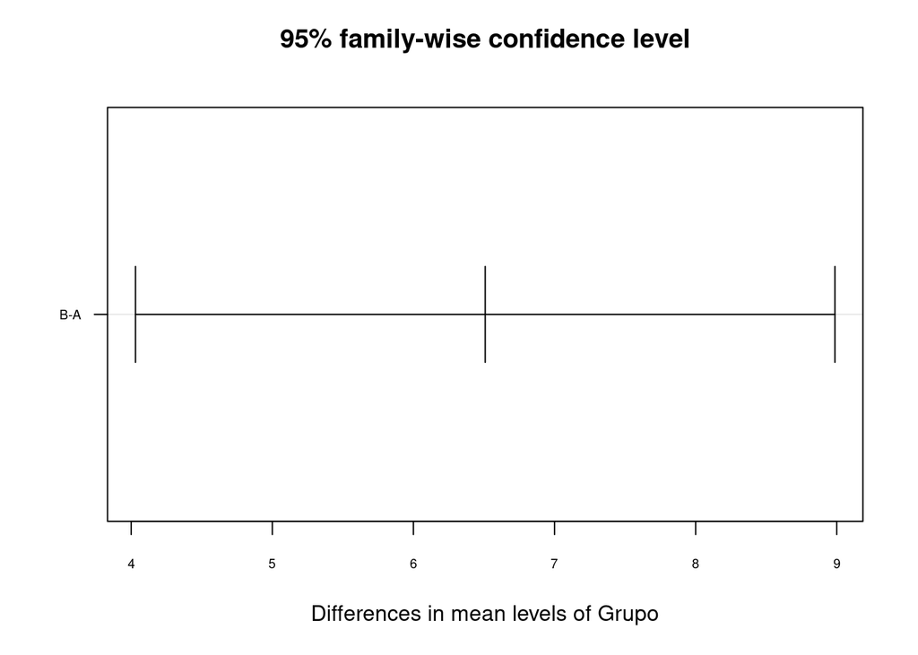

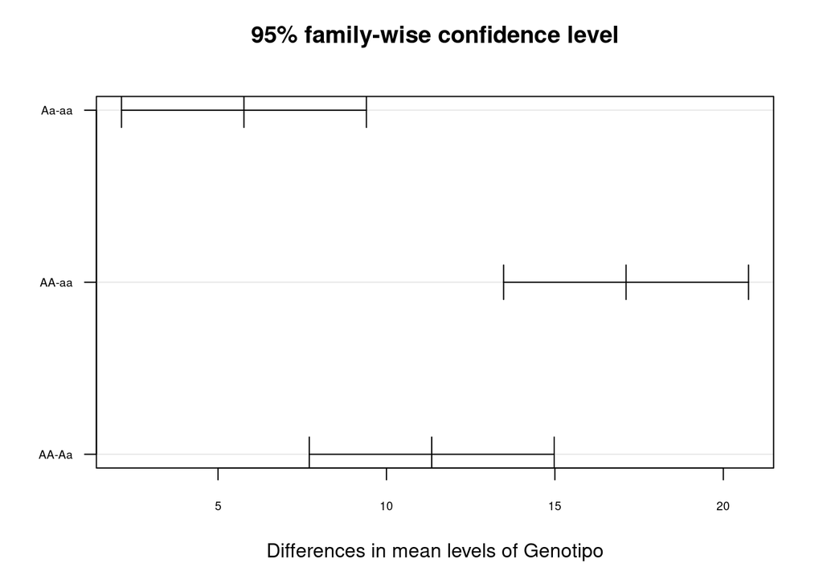

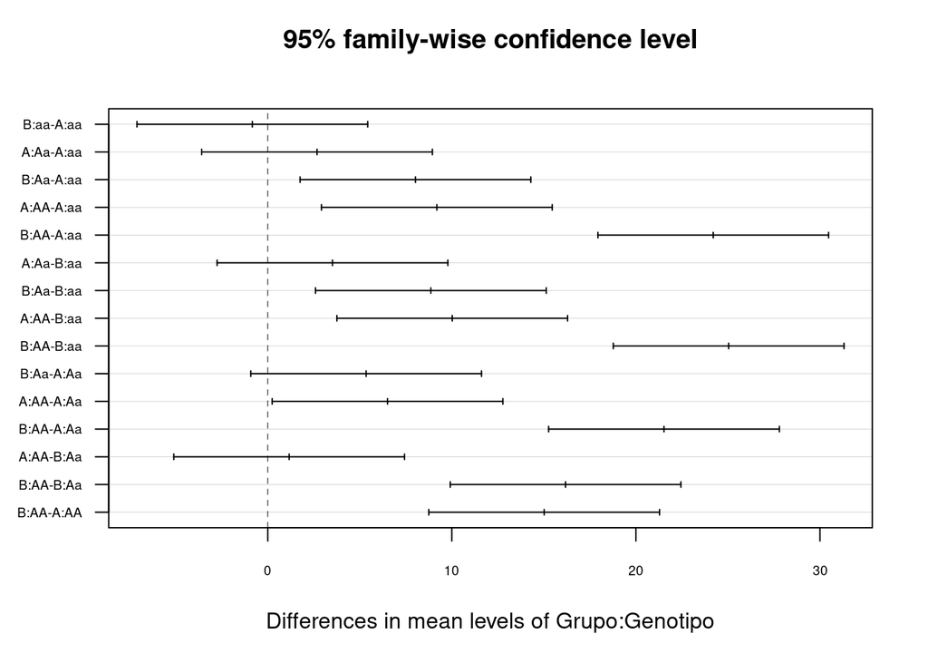

```
##
## --- (iv) SNP como variável quantitativa (efeito aditivo linear) ---
##
## Call:
## lm(formula = Y ~ Grupo * Geno_num, data = dat)
##
## Residuals:
##      Min       1Q   Median       3Q      Max
## -22.6306  -5.0435  -0.5809   6.1423  22.7371
##
## Coefficients:
##                 Estimate Std. Error t value Pr(>|t|)
## (Intercept)       75.596      1.415  53.425  < 2e-16 ***
## GrupoB            -1.419      2.001  -0.709    0.479
## Geno_num           4.592      1.096   4.190 4.41e-05 ***
## GrupoB:Geno_num    7.928      1.550   5.115 8.16e-07 ***
## ---
## Signif. codes:  0 '***' 0.001 '**' 0.01 '*' 0.05 '.' 0.1 ' ' 1
##
## Residual standard error: 8.49 on 176 degrees of freedom
## Multiple R-squared:  0.4978, Adjusted R-squared:  0.4893
## F-statistic: 58.16 on 3 and 176 DF,  p-value: < 2.2e-16
##
## Analysis of Variance Table
##
## Response: Y
##                 Df  Sum Sq Mean Sq F value    Pr(>F)
## Grupo            1  1906.4  1906.4  26.449 7.161e-07 ***
## Geno_num         1  8785.3  8785.3 121.883 < 2.2e-16 ***
## Grupo:Geno_num   1  1885.5  1885.5  26.159 8.158e-07 ***
## Residuals      176 12686.0    72.1
## ---
## Signif. codes:  0 '***' 0.001 '**' 0.01 '*' 0.05 '.' 0.1 ' ' 1
##
## Comparação R²: categórico = 0.511 | quantitativo = 0.498
```

> **Interpretação P3:**

> **Perfil de médias e boxplot:** as linhas do perfil de médias crescem afastando-se, indicando que dessa vez, não podemos assumir independência do efeito do SNP em relação ao subgrupo. O boxplot mostra “shifts” maiores entre genótipos no subgrupo B, evidenciando a interação: o efeito do SNP é mais acentuado em B do que em A.

> **ANOVA:** são significativos ambos o efeito de Grupo(F = 26,87; p < 0,001) e de Genótipo (F = 64,10; p < 0,001). E também é significativa a interação Grupo$\times$Genótipo (F = 13,50; p < 0,001).

> **Diagnóstico:** normalidade (Shapiro-Wilk: W = 0,995; p = 0,811) e homocedasticidade (Bartlett: K² = 3,645; p = 0,602) satisfeitas. O gráfico “Constant Leverage” mostra resíduos bem distribuídos. Já o “Scale-Location” apresenta uma leve inclinação ascendente, sugerindo que a variabilidade dos resíduos tende a aumentar com os valores ajustados. Ainda assim, o teste de Bartlett não rejeita a homocedasticidade, então o padrão observado no gráfico não é estatisticamente relevante com este tamanho amostral.

> **Tukey:** o contraste B-A é significativo (~6,5 mmHg; p < 0,001), indicando diferença entre subgrupos. Todos os contrastes entre genótipos são significativos (Aa-aa: +5,8 mmHg, p < 0,001; AA-aa: +17,1 mmHg, p < 0,001; AA-Aa: +11,3 mmHg, p < 0,001), confirmando o efeito do SNP sobre a pressão diastólica. No Tukey da interação Grupo:Genótipo, o padrão de contrastes revela claramente a interação SNP$\times$subgrupo: dentro do subgrupo A, o efeito do SNP é moderado (A:AA-A:aa: +9,2 mmHg; p < 0,001), enquanto no subgrupo B é muito mais acentuado (B:AA-B:aa: +25,0 mmHg; p < 0,001). Contrastes entre subgrupos dentro do mesmo genótipo mostram que A e B são indistinguíveis em aa (B:aa-A:aa: p = 0,999) mas divergem fortemente em AA (B:AA-A:AA: +15,0 mmHg; p < 0,001), confirmando que a diferença entre subgrupos depende do genótipo — assinatura inequívoca de interação. Estes resultados corroboram a interação significativa observada na ANOVA e o não-paralelismo das linhas no perfil de médias.

> **SNP quantitativo (item iv):** o modelo com `Geno_num` assume e detecta efeito aditivo linear significativo no subgrupo A ($\hat{\beta} = 4,59$ mmHg por alelo A; p < 0,001) e uma interação Grupo$\times$Geno_num altamente significativa ($\hat{\beta} = 7,93$; p < 0,001), indicando que o efeito do SNP é maior por alelo A no subgrupo B do que em A — resultado coerente com a interação detectada no modelo categórico. O efeito principal de Grupo não é significativo (p = 0,479). Isso pode ser justificado pois quando há interação, o efeito de Grupo depende do genótipo, não podendo ser interpretado isoladamente. O R² é ligeiramente inferior ao do modelo categórico (0,498 vs. 0,511), diferença pequena que reflete a restrição de G.L. causada pela adoção da linearidade. A conclusão é a mesma: há interação SNP$\times$grupo significativa, com o efeito do SNP sendo muito mais pronunciado no grupo B.

## 2.3 Item (d) – Combinando as três populações

> A análise conjunta permite avaliar se os efeitos do SNP e do subgrupo são consistentes entre populações ou se há heterogeneidade, questão central em estudos de genética de populações.

### 2.3.1 (d.i) – Fatorial 3 x 2 x 3 : SNP $\times$ Grupo $\times$ Populaçao (todos fixos)

```r
dat_all <- rbind(dat_P1, dat_P2, dat_P3)
dat_all$Pop <- factor(dat_all$Pop) # Transformo população em var. categórica

# Estatísticas descritivas do dataset combinado
desc_all <- describeBy(dat_all$Y,
                       group = list(dat_all$Pop, dat_all$Grupo, dat_all$Genotipo),
                       mat = TRUE)

tabela_all <- desc_all[, c("group1","group2","group3","n","mean","sd","median","min","max")]
rownames(tabela_all) <- NULL

knitr::kable(tabela_all, digits = 2,
             col.names = c("População","Grupo","Genótipo","n","Média","DP","Mediana","Mín","Máx"),
             caption = "Estatísticas descritivas de Y por População, Grupo e Genótipo")
```

Estatísticas descritivas de Y por População, Grupo e Genótipo

| População | Grupo | Genótipo | n | Média | DP | Mediana | Mín | Máx |
| --- | --- | --- | --- | --- | --- | --- | --- | --- |
| P1 | A | aa | 30 | 79.95 | 7.92 | 79.10 | 66.62 | 94.18 |
| P2 | A | aa | 30 | 74.03 | 9.13 | 74.11 | 54.91 | 92.07 |
| P3 | A | aa | 30 | 76.23 | 7.10 | 75.47 | 60.13 | 93.82 |
| P1 | B | aa | 30 | 90.51 | 9.23 | 90.51 | 75.07 | 107.78 |
| P2 | B | aa | 30 | 79.11 | 7.25 | 78.43 | 63.70 | 91.86 |
| P3 | B | aa | 30 | 75.40 | 8.69 | 74.82 | 55.89 | 95.17 |
| P1 | A | Aa | 30 | 78.93 | 9.11 | 79.71 | 60.14 | 94.87 |
| P2 | A | Aa | 30 | 79.76 | 8.37 | 79.23 | 65.14 | 98.32 |
| P3 | A | Aa | 30 | 78.91 | 7.77 | 78.46 | 60.86 | 94.20 |
| P1 | B | Aa | 30 | 91.34 | 6.16 | 90.93 | 78.77 | 112.20 |
| P2 | B | Aa | 30 | 84.61 | 7.90 | 83.63 | 73.61 | 103.71 |
| P3 | B | Aa | 30 | 84.26 | 7.96 | 84.10 | 66.69 | 99.87 |
| P1 | A | AA | 30 | 78.98 | 5.76 | 78.81 | 66.94 | 93.31 |
| P2 | A | AA | 30 | 90.08 | 7.68 | 89.23 | 79.32 | 114.47 |
| P3 | A | AA | 30 | 85.42 | 9.07 | 84.44 | 62.15 | 101.10 |
| P1 | B | AA | 30 | 89.59 | 7.35 | 90.83 | 72.80 | 104.50 |
| P2 | B | AA | 30 | 98.91 | 8.27 | 101.49 | 76.34 | 114.68 |
| P3 | B | AA | 30 | 100.44 | 9.68 | 101.09 | 81.02 | 121.95 |

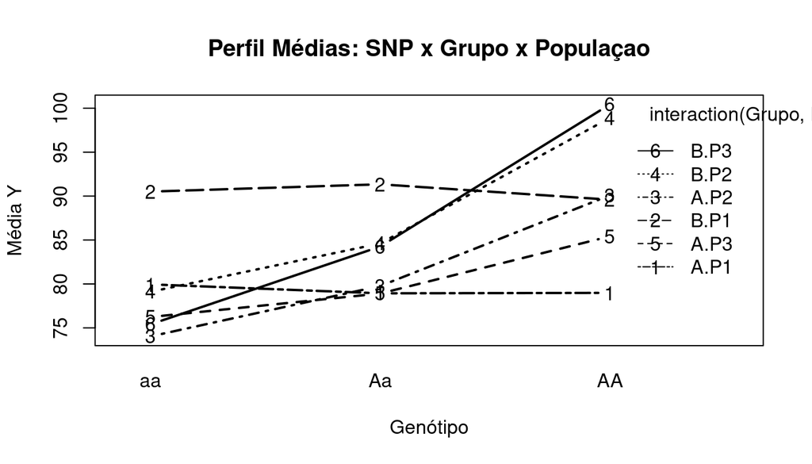

```r
# Perfil de médias
with(dat_all,
     interaction.plot(Genotipo, interaction(Grupo,Pop), Y,
                      main="Perfil Médias: SNP x Grupo x Populaçao",
                      xlab="Genótipo", ylab="Média Y",
                      lwd=2, type="b"))
```

```r
# Modelo completo 3x2x3
fit_fixo <- aov(Y ~ Grupo * Genotipo * Pop, data = dat_all)
summary(fit_fixo)
```

```
##                     Df Sum Sq Mean Sq F value   Pr(>F)
## Grupo                1   8603    8603 131.492  < 2e-16 ***
## Genotipo             2  12069    6034  92.227  < 2e-16 ***
## Pop                  2    195      97   1.490 0.226376
## Grupo:Genotipo       2    979     490   7.485 0.000624 ***
## Grupo:Pop            2    697     348   5.323 0.005145 **
## Genotipo:Pop         4   7151    1788  27.324  < 2e-16 ***
## Grupo:Genotipo:Pop   4   1120     280   4.278 0.002049 **
## Residuals          522  34153      65
## ---
## Signif. codes:  0 '***' 0.001 '**' 0.01 '*' 0.05 '.' 0.1 ' ' 1
```

```r
# Coeficientes do modelo
fit_fixo$coef
```

```
##             (Intercept)                  GrupoB              GenotipoAa              GenotipoAA                   PopP2                   PopP3       GrupoB:GenotipoAa
##             79.95232024             10.55691612             -1.01984317             -0.96910237             -5.92343891             -3.71812686              1.85320676
##       GrupoB:GenotipoAA            GrupoB:PopP2            GrupoB:PopP3        GenotipoAa:PopP2        GenotipoAA:PopP2        GenotipoAa:PopP3        GenotipoAA:PopP3
##              0.05166645             -5.48055866            -11.39455950              6.75534045             17.02441215              3.69742933             10.15383941
## GrupoB:GenotipoAa:PopP2 GrupoB:GenotipoAA:PopP2 GrupoB:GenotipoAa:PopP3 GrupoB:GenotipoAA:PopP3
##             -2.08533317              3.69610359              4.33035631             15.80411113
```

> **Modelo (d.i) — População como fator fixo:** `Y ~ Grupo * Genotipo * Pop` inclui todos os efeitos principais e interações de 2ª e 3ª ordem (17 g.l. de tratamento). Grupo (F = 131,5; p < 0,001) e Genótipo (F = 92,2; p < 0,001) são significativos, mas Pop isoladamente não (F = 1,49; p = 0,226). A interação tripla Grupo$\times$Genótipo$\times$Pop é significativa (F = 4,28; p = 0,002), confirmando que o padrão de interação SNP$\times$subgrupo é heterogêneo entre populações — como visível no gráfico, onde as inclinações diferem marcadamente entre P1, P2 e P3.

### 2.3.2 (d.ii) – Fatorial 3 x 2 com Populaçao como fator aleatório (ANOVA Mista)

```r
library(lme4)

# Modelo misto: Population como efeito aleatório (intercepto aleatório por Pop)
fit_misto <- lmer(Y ~ Grupo * Genotipo * (1 | Pop), data = dat_all)
summary(fit_misto)
```

```
## Linear mixed model fit by REML. t-tests use Satterthwaite's method ['lmerModLmerTest']
## Formula: Y ~ Grupo * Genotipo * (1 | Pop)
##    Data: dat_all
##
## REML criterion at convergence: 3889.8
##
## Scaled residuals:
##     Min      1Q  Median      3Q     Max
## -2.8484 -0.6599 -0.0410  0.6774  3.2897
##
## Random effects:
##  Groups   Name        Variance Std.Dev.
##  Pop      (Intercept)  0.09122 0.302
##  Residual             81.05413 9.003
## Number of obs: 540, groups:  Pop, 3
##
## Fixed effects:
##                   Estimate Std. Error       df t value Pr(>|t|)
## (Intercept)        76.7385     0.9649  49.9573  79.531  < 2e-16 ***
## GrupoB              4.9319     1.3421 532.0000   3.675 0.000262 ***
## GenotipoAa          2.4644     1.3421 532.0000   1.836 0.066878 .
## GenotipoAA          8.0903     1.3421 532.0000   6.028  3.1e-09 ***
## GrupoB:GenotipoAa   2.6015     1.8980 532.0000   1.371 0.171053
## GrupoB:GenotipoAA   6.5517     1.8980 532.0000   3.452 0.000601 ***
## ---
## Signif. codes:  0 '***' 0.001 '**' 0.01 '*' 0.05 '.' 0.1 ' ' 1
##
## Correlation of Fixed Effects:
##             (Intr) GrupoB GentpA GntpAA GrB:GA
## GrupoB      -0.695
## GenotipoAa  -0.695  0.500
## GenotipoAA  -0.695  0.500  0.500
## GrupB:GntpA  0.492 -0.707 -0.707 -0.354
## GrpB:GntpAA  0.492 -0.707 -0.354 -0.707  0.500
```

```r
# Coeficientes do modelo
print(coef(fit_misto))
```

```
## $Pop
##    (Intercept)   GrupoB GenotipoAa GenotipoAA GrupoB:GenotipoAa GrupoB:GenotipoAA
## P1    76.84579 4.931877   2.464413   8.090315          2.601548          6.551738
## P2    76.76683 4.931877   2.464413   8.090315          2.601548          6.551738
## P3    76.60277 4.931877   2.464413   8.090315          2.601548          6.551738
##
## attr(,"class")
## [1] "coef.mer"
```

```r
# IC dos efeitos fixos
confint(fit_misto, method="Wald")
```

```
##                        2.5 %    97.5 %
## .sig01                    NA        NA
## .sigma                    NA        NA
## (Intercept)       74.8473185 78.629611
## GrupoB             2.3014306  7.562323
## GenotipoAa        -0.1660327  5.094860
## GenotipoAA         5.4598687 10.720761
## GrupoB:GenotipoAa -1.1184648  6.321560
## GrupoB:GenotipoAA  2.8317255 10.271751
```

```r
# IC profile
confint(fit_misto)
```

```
##                        2.5 %    97.5 %
## .sig01             0.0000000  1.692875
## .sigma             8.4475286  9.518151
## (Intercept)       74.8848240 78.592106
## GrupoB             2.3104325  7.553321
## GenotipoAa        -0.1570308  5.085858
## GenotipoAA         5.4688706 10.711759
## GrupoB:GenotipoAa -1.1057342  6.308830
## GrupoB:GenotipoAA  2.8444560 10.259020
```

```r
# IC bootstrap
confint(fit_misto, method="boot", nsim=1000)
```

```
##                        2.5 %    97.5 %
## .sig01             0.0000000  1.273450
## .sigma             8.4489750  9.610272
## (Intercept)       74.9202306 78.620777
## GrupoB             2.1563800  7.565635
## GenotipoAa        -0.2005394  5.003334
## GenotipoAA         5.5990832 10.919747
## GrupoB:GenotipoAa -1.2031479  6.192034
## GrupoB:GenotipoAA  2.6301816 10.408517
```

> **Modelo (d.ii) — População como fator aleatório:** `Y ~ Grupo * Genotipo * (1|Pop)` a população como efeito aleatório não se mostrou importante para o conjunto de dados. A variância praticamente nula (0,091) em relação ao resíduo (81,054) indica que a heterogeneidade entre populações é pequena comparada à variação dentro das populações. Os efeitos fixos de `GrupoB` e `GenotipoAA` permanecem altamente significativos (p < 0,001), assim como a interação `GrupoB:GenotipoAA`. Então, embora no modelo d.i a interação de População como efeito fixo com os demais fatores fosse importante, ao considerá-la aleatória, o efeito de grupo e genótipo se sobressaem. Nesse caso então, uma generalização dos efeitos de Grupo e Genótipo para além das três populações observadas é plausível e sustentada pelos dados: a estabilidade dos efeitos fixos entre populações sugere que a associação do SNP e do fator de grupo com a pressão diastólica não é específica de população. Contudo, essa conclusão deve ser interpretada com cautela, pois com apenas três populações o modelo aleatório não possui poder suficiente para estimar com precisão a variabilidade interpopulacional no universo amostral. Os intervalos de confiança para o desvio-padrão do efeito aleatório (.sig01) incluem zero em ambos os métodos avaliados (profile e bootstrap). Portanto, a ausência de variância interpopulacional detectável pode refletir tanto homogeneidade real entre populações quanto limitação de poder amostral.

# 3 Regressão Logística: Y dicotomizada

## 3.1 Dicotomização de Y

```r
# Ponto de corte: mediana global de cada dataset
corte1 <- median(dat1$Y)
corte2 <- median(dat2$Y)
corte_all <- median(dat_all$Y)

dat1$Ybin <- as.factor(ifelse(dat1$Y > corte1, 1, 0))
dat2$Ybin <- as.factor(ifelse(dat2$Y > corte2, 1, 0))
dat_all$Ybin <- as.factor(ifelse(dat_all$Y > corte_all, 1, 0))

cat("Ponto de corte Q1:", corte1, " | Distribuição:\n"); print(table(dat1$Ybin))
```

```
## Ponto de corte Q1: 108.5428  | Distribuição:
```

```
##
##   0   1
## 150 150
```

```r
tab1 <- table(factor(dat1$Ybin, labels = c("baixo", "alto")), dat1$SNP)
tab1 <- rbind(tab1, "total" = colSums(tab1))
tab1
```

```
##        aa  Aa AA
## baixo 137  13  0
## alto   11 110 29
## total 148 123 29
```

```r
cat("Ponto de corte Q2:", corte2, " | Distribuição:\n"); print(table(dat2$Ybin))
```

```
## Ponto de corte Q2: 99.32791  | Distribuição:
```

```
##
##   0   1
## 450 450
```

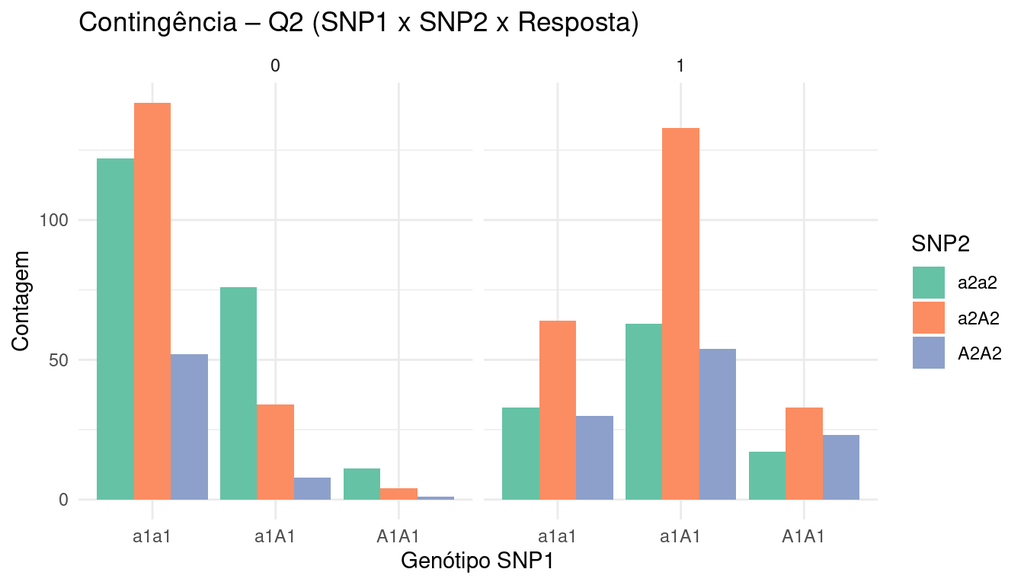

```r
plot <- ggplot2::ggplot(dat2, ggplot2::aes(x = SNP1, fill = SNP2)) +
  ggplot2::geom_bar(position = ggplot2::position_dodge()) +
  ggplot2::facet_wrap(~ Ybin) +
  ggplot2::scale_fill_brewer(type = "qual", palette = "Set2", name = "SNP2") +
  ggplot2::labs(
    title = "Contingência – Q2 (SNP1 x SNP2 x Resposta)",
    x = "Genótipo SNP1",
    y = "Contagem"
  ) +
  ggplot2::theme_minimal()

print(plot)
```

## 3.2 Questão 1 (Caso 1) – Regressão Logística

```r
# Modelo logístico
fitrl1_ad <- glm(as.factor(Ybin) ~ xa + xd, family=binomial(link="logit"), data=dat1)
summary(fitrl1_ad)
```

```
##
## Call:
## glm(formula = as.factor(Ybin) ~ xa + xd, family = binomial(link = "logit"),
##     data = dat1)
##
## Coefficients:
##             Estimate Std. Error z value Pr(>|z|)
## (Intercept)    8.022    605.612   0.013    0.989
## xa            10.544    605.612   0.017    0.986
## xd            -5.886    605.612  -0.010    0.992
##
## (Dispersion parameter for binomial family taken to be 1)
##
##     Null deviance: 415.89  on 299  degrees of freedom
## Residual deviance: 161.35  on 297  degrees of freedom
## AIC: 167.35
##
## Number of Fisher Scoring iterations: 17
```

```r
cat("\nOR estimado (exp(coef)):\n")
```

```
##
## OR estimado (exp(coef)):
```

```r
print(exp(coef(fitrl1_ad)))
```

```
##  (Intercept)           xa           xd
## 3.047240e+03 3.795198e+04 2.776788e-03
```

```r
cat("\nIC para OR:\n")
```

```
##
## IC para OR:
```

```r
print(exp(confint(fitrl1_ad)))
```

```
##                    2.5 %       97.5 %
## (Intercept) 1.339586e-17           NA
## xa          2.516933e-09 4.004769e+80
## xd                    NA 1.777731e+12
```

```r
# Probabilidades preditas e tabela de classificação
pred1r <- predict(fitrl1_ad, type="response")
class1r <- ifelse(pred1r >= 0.5, 1, 0)
cat("Tabela de classificação:\n")
```

```
## Tabela de classificação:
```

```r
print(table(Predito=class1r, Observado=dat1$Ybin))
```

```
##        Observado
## Predito   0   1
##       0 137  11
##       1  13 139
```

```r
cat("Acurácia:", round(mean(class1r == dat1$Ybin), 3), "\n")
```

```
## Acurácia: 0.92
```

> **Regressão Logística – Q1 Caso 1:** O estabelecimento do valor corte para dicotomização de Y na mediana dos dados causou um fenômeno de separação completa dos grupos devido à ausência de observações “baixas” para o genótipo `AA`. Isso fez o modelo de regressão logística não recuperar adequadamente os coeficientes para os efeitos aditivo e de dominância, que tiveram a significância ignorada. Decidimos então voltar atrás e definir arbitrariamente um valor de corte que não deixasse valores nulos na tabela de contingência “altos *versus* baixos.”

```r
corte1 <- 111
dat1$Ybin <- as.factor(ifelse(dat1$Y > corte1, 1, 0))

cat("Ponto de corte Q1:", corte1, " | Distribuição:\n"); print(table(dat1$Ybin))
```

```
## Ponto de corte Q1: 111  | Distribuição:
```

```
##
##   0   1
## 173 127
```

```r
tab1 <- table(factor(dat1$Ybin, labels = c("baixo", "alto")), dat1$SNP)
tab1 <- rbind(tab1, "total" = colSums(tab1))
tab1
```

```
##        aa  Aa AA
## baixo 144  27  2
## alto    4  96 27
## total 148 123 29
```

```r
fitrl1_ad <- glm(as.factor(Ybin) ~ xa + xd, family=binomial(link="logit"), data=dat1)
summary(fitrl1_ad)
```

```
##
## Call:
## glm(formula = as.factor(Ybin) ~ xa + xd, family = binomial(link = "logit"),
##     data = dat1)
##
## Coefficients:
##             Estimate Std. Error z value Pr(>|z|)
## (Intercept)  -0.4904     0.4455  -1.101  0.27101
## xa            3.0931     0.4455   6.943 3.85e-12 ***
## xd            1.7589     0.4959   3.547  0.00039 ***
## ---
## Signif. codes:  0 '***' 0.001 '**' 0.01 '*' 0.05 '.' 0.1 ' ' 1
##
## (Dispersion parameter for binomial family taken to be 1)
##
##     Null deviance: 408.81  on 299  degrees of freedom
## Residual deviance: 180.80  on 297  degrees of freedom
## AIC: 186.8
##
## Number of Fisher Scoring iterations: 6
```

```r
cat("\nOR estimado (exp(coef)):\n")
```

```
##
## OR estimado (exp(coef)):
```

```r
print(exp(coef(fitrl1_ad)))
```

```
## (Intercept)          xa          xd
##   0.6123724  22.0454077   5.8061979
```

```r
cat("\nIC para OR:\n")
```

```
##
## IC para OR:
```

```r
print(exp(confint(fitrl1_ad)))
```

```
##                  2.5 %    97.5 %
## (Intercept)  0.2636769  1.673448
## xa          10.2133711 61.911080
## xd           1.9757020 14.980133
```

```r
pred1r <- predict(fitrl1_ad, type="response")
class1r <- ifelse(pred1r >= 0.5, 1, 0)
cat("Tabela de classificação:\n")
```

```
## Tabela de classificação:
```

```r
print(table(Predito=class1r, Observado=dat1$Ybin))
```

```
##        Observado
## Predito   0   1
##       0 144   4
##       1  29 123
```

```r
cat("Acurácia:", round(mean(class1r == dat1$Ybin), 3), "\n")
```

```
## Acurácia: 0.89
```

> **Regressão Logística – Q1 Caso 1 (com corte arbitrário):** Dessa vez, conseguimos evitar a separação total dos grupos, possibilitando que o modelo recuperasse adequadamente os coeficientes, resultando em $\log(\frac{\rho}{1-\rho}) = -0.4904 + 3.0931\times x_a + 1.7589\times x_d$, com significância para ambos ($p_{x_a} = 3.85 \times 10^{-12}$; $p_{x_d} = 0.00039$).

## 3.3 Questão 1 (Caso 2) – Regressão Logística com dois SNPs

```r
fitrl2 <- glm(Ybin ~ xa1 + xd1 + xa2 + xd2 +
                     xa1:xa2 + xa1:xd2 + xd1:xa2 + xd1:xd2,
              family=binomial(link="logit"), data=dat2)
summary(fitrl2)
```

```
##
## Call:
## glm(formula = Ybin ~ xa1 + xd1 + xa2 + xd2 + xa1:xa2 + xa1:xd2 +
##     xd1:xa2 + xd1:xd2, family = binomial(link = "logit"), data = dat2)
##
## Coefficients:
##             Estimate Std. Error z value Pr(>|z|)
## (Intercept)  0.42831    0.28327   1.512  0.13052
## xa1          1.35709    0.28327   4.791 1.66e-06 ***
## xd1          0.43266    0.35125   1.232  0.21804
## xa2          0.86441    0.28327   3.052  0.00228 **
## xd2          0.22832    0.39495   0.578  0.56319
## xa1:xa2      0.48568    0.28327   1.715  0.08643 .
## xa1:xd2      0.09649    0.39495   0.244  0.80700
## xd1:xa2      0.18416    0.35125   0.524  0.60007
## xd1:xd2      0.27470    0.48585   0.565  0.57181
## ---
## Signif. codes:  0 '***' 0.001 '**' 0.01 '*' 0.05 '.' 0.1 ' ' 1
##
## (Dispersion parameter for binomial family taken to be 1)
##
##     Null deviance: 1247.7  on 899  degrees of freedom
## Residual deviance: 1002.6  on 891  degrees of freedom
## AIC: 1020.6
##
## Number of Fisher Scoring iterations: 5
```

```r
cat("\nOR estimados:\n")
```

```
##
## OR estimados:
```

```r
print(round(exp(coef(fitrl2)), 3))
```

```
## (Intercept)         xa1         xd1         xa2         xd2     xa1:xa2     xa1:xd2     xd1:xa2     xd1:xd2
##       1.535       3.885       1.541       2.374       1.256       1.625       1.101       1.202       1.316
```

```r
cat("\nIC para OR:\n")
```

```
##
## IC para OR:
```

```r
print(round(exp(confint(fitrl2)), 3))
```

```
##             2.5 % 97.5 %
## (Intercept) 0.961  3.247
## xa1         2.433  8.221
## xd1         0.675  2.949
## xa2         1.483  5.021
## xd2         0.524  2.740
## xa1:xa2     1.015  3.438
## xa1:xd2     0.459  2.402
## xd1:xa2     0.527  2.302
## xd1:xd2     0.506  3.623
```

```r
pred2r <- predict(fitrl2, type="response")
class2r <- ifelse(pred2r >= 0.5, 1, 0)
cat("Tabela de classificação:\n")
```

```
## Tabela de classificação:
```

```r
print(table(Predito=class2r, Observado=dat2$Ybin))
```

```
##        Observado
## Predito   0   1
##       0 392 190
##       1  58 260
```

```r
cat("Acurácia:", round(mean(class2r == dat2$Ybin), 3), "\n")
```

```
## Acurácia: 0.724
```

```r
corte2 <- 105
dat2$Ybin <- as.factor(ifelse(dat2$Y > corte2, 1, 0))

cat("Ponto de corte Q2:", corte2, " | Distribuição:\n"); print(table(dat2$Ybin))
```

```
## Ponto de corte Q2: 105  | Distribuição:
```

```
##
##   0   1
## 574 326
```

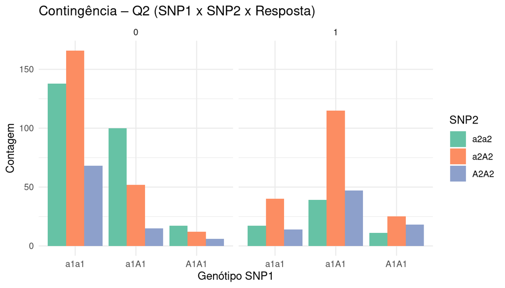

```r
plot <- ggplot2::ggplot(dat2, ggplot2::aes(x = SNP1, fill = SNP2)) +
  ggplot2::geom_bar(position = ggplot2::position_dodge()) +
  ggplot2::facet_wrap(~ Ybin) +
  ggplot2::scale_fill_brewer(type = "qual", palette = "Set2", name = "SNP2") +
  ggplot2::labs(
    title = "Contingência – Q2 (SNP1 x SNP2 x Resposta)",
    x = "Genótipo SNP1",
    y = "Contagem"
  ) +
  ggplot2::theme_minimal()

print(plot)
```

```r
fitrl2 <- glm(Ybin ~ xa1 + xd1 + xa2 + xd2 +
                     xa1:xa2 + xa1:xd2 + xd1:xa2 + xd1:xd2,
              family=binomial(link="logit"), data=dat2)
summary(fitrl2)
```

```
##
## Call:
## glm(formula = Ybin ~ xa1 + xd1 + xa2 + xd2 + xa1:xa2 + xa1:xd2 +
##     xd1:xa2 + xd1:xd2, family = binomial(link = "logit"), data = dat2)
##
## Coefficients:
##              Estimate Std. Error z value Pr(>|z|)
## (Intercept) -0.752799   0.180996  -4.159 3.19e-05 ***
## xa1          1.084446   0.180996   5.992 2.08e-09 ***
## xd1          0.853044   0.252301   3.381 0.000722 ***
## xa2          0.511880   0.180996   2.828 0.004682 **
## xd2          0.408230   0.267112   1.528 0.126437
## xa1:xa2      0.255085   0.180996   1.409 0.158735
## xa1:xd2     -0.005907   0.267112  -0.022 0.982355
## xd1:xa2      0.529973   0.252301   2.101 0.035680 *
## xd1:xd2      0.285214   0.360793   0.791 0.429223
## ---
## Signif. codes:  0 '***' 0.001 '**' 0.01 '*' 0.05 '.' 0.1 ' ' 1
##
## (Dispersion parameter for binomial family taken to be 1)
##
##     Null deviance: 1178.43  on 899  degrees of freedom
## Residual deviance:  936.85  on 891  degrees of freedom
## AIC: 954.85
##
## Number of Fisher Scoring iterations: 4
```

```r
cat("\nOR estimados:\n")
```

```
##
## OR estimados:
```

```r
print(round(exp(coef(fitrl2)), 3))
```

```
## (Intercept)         xa1         xd1         xa2         xd2     xa1:xa2     xa1:xd2     xd1:xa2     xd1:xd2
##       0.471       2.958       2.347       1.668       1.504       1.291       0.994       1.699       1.330
```

```r
cat("\nIC para OR:\n")
```

```
##
## IC para OR:
```

```r
print(round(exp(confint(fitrl2)), 3))
```

```
##             2.5 % 97.5 %
## (Intercept) 0.331  0.676
## xa1         2.088  4.264
## xd1         1.432  3.864
## xa2         1.178  2.405
## xd2         0.893  2.554
## xa1:xa2     0.912  1.862
## xa1:xd2     0.589  1.686
## xd1:xa2     1.036  2.794
## xd1:xd2     0.653  2.694
```

```r
pred2r <- predict(fitrl2, type="response")
class2r <- ifelse(pred2r >= 0.5, 1, 0)
cat("Tabela de classificação:\n")
```

```
## Tabela de classificação:
```

```r
print(table(Predito=class2r, Observado=dat2$Ybin))
```

```
##        Observado
## Predito   0   1
##       0 489 121
##       1  85 205
```

```r
cat("Acurácia:", round(mean(class2r == dat2$Ybin), 3), "\n")
```

```
## Acurácia: 0.771
```

> **Regressão Logística – Q1 Caso 2 (corte manual):** Foi desafiador definir um valor de corte que gerasse uma separação mais equilibrada entre os grupos, mas com o corte em 105, conseguimos ao menos evitar grupos zerados ou com representações excessivamente baixas. Apesar disso, notamos que o modelo logístico apresentou perda de significância em relação à ANOVA para o efeito de dominância do SNP2 e para a interação `xa1:xa2`. Esse cenário, inclusive, mostrou-se facilmente influenciado pelos vários valores de corte que experimentamos. Hora era detectada significância de alguns efeitos, hora de outros. O teste preditivo melhorou um pouco em relação à definição do corte na mediana (de 72,4% para 77,1%), mas ainda assim ficou aquém do ideal, reforçando a limitação. Podemos ver que houve impacto significativo na adoção da categorização da resposta Y. Tornou-se mais desafiador por conta, acreditamos, das grandes separação e dispersão existentes nos dados. Entretanto, já que no ANOVA nós trabalhamos com um modelo reduzido, decidimos experimentar a mesma abordagem aqui, removendo efeitos que antes não haviam sido dados como significativos, a fim de focar nos efeitos de interesse.

```r
fitrl2_reduzido <- glm(Ybin ~ xa1 + xd1 + xa2 + xd2 +
                              xa1:xa2 + xd1:xa2,
              family=binomial(link="logit"), data=dat2)
summary(fitrl2_reduzido)
```

```
##
## Call:
## glm(formula = Ybin ~ xa1 + xd1 + xa2 + xd2 + xa1:xa2 + xd1:xa2,
##     family = binomial(link = "logit"), data = dat2)
##
## Coefficients:
##             Estimate Std. Error z value Pr(>|z|)
## (Intercept)  -0.8195     0.1564  -5.239 1.62e-07 ***
## xa1           1.0909     0.1333   8.186 2.69e-16 ***
## xd1           0.9992     0.1800   5.552 2.82e-08 ***
## xa2           0.5015     0.1808   2.774  0.00553 **
## xd2           0.5443     0.1674   3.252  0.00115 **
## xa1:xa2       0.2544     0.1803   1.411  0.15830
## xd1:xa2       0.5753     0.2487   2.313  0.02071 *
## ---
## Signif. codes:  0 '***' 0.001 '**' 0.01 '*' 0.05 '.' 0.1 ' ' 1
##
## (Dispersion parameter for binomial family taken to be 1)
##
##     Null deviance: 1178.43  on 899  degrees of freedom
## Residual deviance:  937.56  on 893  degrees of freedom
## AIC: 951.56
##
## Number of Fisher Scoring iterations: 4
```

```r
cat("\nOR estimados:\n")
```

```
##
## OR estimados:
```

```r
print(round(exp(coef(fitrl2_reduzido)), 3))
```

```
## (Intercept)         xa1         xd1         xa2         xd2     xa1:xa2     xd1:xa2
##       0.441       2.977       2.716       1.651       1.723       1.290       1.778
```

```r
cat("\nIC para OR:\n")
```

```
##
## IC para OR:
```

```r
print(round(exp(confint(fitrl2_reduzido)), 3))
```

```
##             2.5 % 97.5 %
## (Intercept) 0.324  0.600
## xa1         2.302  3.888
## xd1         1.908  3.868
## xa2         1.165  2.374
## xd2         1.241  2.395
## xa1:xa2     0.911  1.853
## xd1:xa2     1.091  2.899
```

```r
pred2r <- predict(fitrl2_reduzido, type="response")
class2r <- ifelse(pred2r >= 0.5, 1, 0)
cat("Tabela de classificação:\n")
```

```
## Tabela de classificação:
```

```r
print(table(Predito=class2r, Observado=dat2$Ybin))
```

```
##        Observado
## Predito   0   1
##       0 489 121
##       1  85 205
```

```r
cat("Acurácia:", round(mean(class2r == dat2$Ybin), 3), "\n")
```

```
## Acurácia: 0.771
```

```r
anova(fitrl2_reduzido, fitrl2)
```

```
## Analysis of Deviance Table
##
## Model 1: Ybin ~ xa1 + xd1 + xa2 + xd2 + xa1:xa2 + xd1:xa2
## Model 2: Ybin ~ xa1 + xd1 + xa2 + xd2 + xa1:xa2 + xa1:xd2 + xd1:xa2 +
##     xd1:xd2
##   Resid. Df Resid. Dev Df Deviance Pr(>Chi)
## 1       893     937.56
## 2       891     936.85  2  0.71429   0.6997
```

> **Regressão Logística – Q1 Caso 2 (modelo reduzido):** Agora, com um modelo reduzido, baseado naquele que utilizamos no ANOVA, conseguimos recuperar a significância para o efeito de dominância do SNP2, mas não o efeito da interação `xa1:xa2`. A acurácia preditiva permaneceu igual (77,1%), corroborando o resultado da ANOVA comparando o modelo reduzido ao logístico original (p = 0.6997). Acreditamos então, depois de tantas tentativas, que a regressão logística para esse caso é inadequada por gerar perda de informação.

## 3.4 Questão 2 – Regressão Logística por População

```
##
##
## ==============================
##  POPULAÇÃO: P1
## ==============================
```

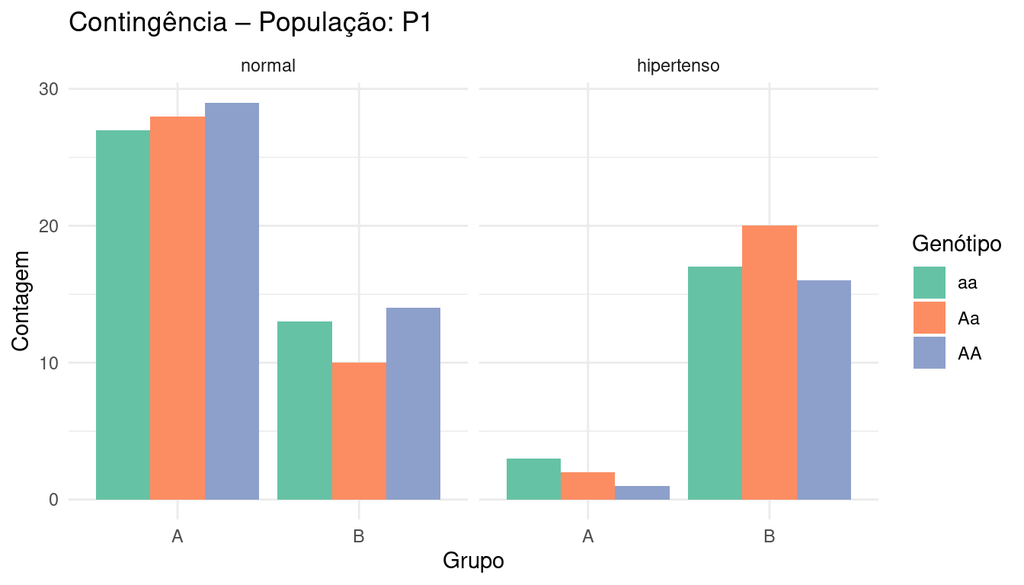

```
##
## Modelo logístico – fator categórico:
##
## Call:
## glm(formula = Ybin ~ Grupo * Genotipo, family = binomial(link = "logit"),
##     data = dat)
##
## Coefficients:
##                   Estimate Std. Error z value Pr(>|z|)
## (Intercept)        -2.1972     0.6086  -3.610 0.000306 ***
## GrupoB              2.4655     0.7114   3.466 0.000529 ***
## GenotipoAa         -0.4418     0.9519  -0.464 0.642529
## GenotipoAA         -1.1701     1.1853  -0.987 0.323554
## GrupoB:GenotipoAa   0.8667     1.0917   0.794 0.427250
## GrupoB:GenotipoAA   1.0353     1.2940   0.800 0.423661
## ---
## Signif. codes:  0 '***' 0.001 '**' 0.01 '*' 0.05 '.' 0.1 ' ' 1
##
## (Dispersion parameter for binomial family taken to be 1)
##
##     Null deviance: 227.73  on 179  degrees of freedom
## Residual deviance: 163.67  on 174  degrees of freedom
## AIC: 175.67
##
## Number of Fisher Scoring iterations: 6
##
##
## OR estimados:
##       (Intercept)            GrupoB        GenotipoAa        GenotipoAA GrupoB:GenotipoAa GrupoB:GenotipoAA
##             0.111            11.769             0.643             0.310             2.379             2.816
##
## Acurácia: 0.761
##
## Modelo logístico – genótipo quantitativo:
##
## Call:
## glm(formula = Ybin ~ Grupo * Geno_num, family = binomial(link = "logit"),
##     data = dat)
##
## Coefficients:
##                 Estimate Std. Error z value Pr(>|z|)
## (Intercept)      -2.1680     0.5708  -3.798 0.000146 ***
## GrupoB            2.5965     0.6647   3.906 9.37e-05 ***
## Geno_num         -0.5599     0.5531  -1.012 0.311401
## GrupoB:Geno_num   0.4910     0.6122   0.802 0.422555
## ---
## Signif. codes:  0 '***' 0.001 '**' 0.01 '*' 0.05 '.' 0.1 ' ' 1
##
## (Dispersion parameter for binomial family taken to be 1)
##
##     Null deviance: 227.73  on 179  degrees of freedom
## Residual deviance: 164.83  on 176  degrees of freedom
## AIC: 172.83
##
## Number of Fisher Scoring iterations: 5
##
##
## OR estimados:
##     (Intercept)          GrupoB        Geno_num GrupoB:Geno_num
##           0.114          13.417           0.571           1.634
##
## Acurácia: 0.761
```

```r
logistica_pop <- function(dat, nome) {
  cat("\n\n==============================\n")
  cat(" POPULAÇÃO:", nome, "\n==============================\n")

  # Dicotomizar Y
  corte_local <- 90 # escolhemos um corte fixo aqui por conhecermos a natureza biológica dos dados (assumimos que se trata de pressão diastólica em repouso)
  dat$Ybin <- as.factor(ifelse(dat$Y > corte_local, 1, 0))

  # Visualizando contingência dos dados dicotomizados
  plot <- ggplot2::ggplot(dat, ggplot2::aes(x = Grupo, fill = Genotipo)) +
            ggplot2::geom_bar(position = ggplot2::position_dodge()) +
            ggplot2::facet_wrap(
              ~ Ybin,
              labeller = ggplot2::labeller(Ybin = c("0" = "normal", "1" = "hipertenso"))
            ) +
            ggplot2::scale_fill_brewer(type = "qual", palette = "Set2", name = "Genótipo") +
            ggplot2::labs(
              title = paste0("Contingência – População: ", nome),
              x = "Grupo",
              y = "Contagem"
            ) +
            ggplot2::theme_minimal()

  print(plot)

  # Fit do modelo logístico
  fit_logit <- glm(Ybin ~ Grupo * Genotipo,
                   family=binomial(link="logit"), data=dat)
  cat("\nModelo logístico – fator categórico:\n")
  print(summary(fit_logit))
  cat("\nOR estimados:\n")
  print(round(exp(coef(fit_logit)), 3))

  # Prob preditas
  pred_r <- predict(fit_logit, type="response")
  class_r <- ifelse(pred_r >= 0.5, 1, 0)
  cat("\nAcurácia:", round(mean(class_r == dat$Ybin), 3), "\n")

  # Fit do modelo logístico com Genótipo quantitativo
  fit_logit <- glm(Ybin ~ Grupo * Geno_num,
                   family=binomial(link="logit"), data=dat)
  cat("\nModelo logístico – genótipo quantitativo:\n")
  print(summary(fit_logit))
  cat("\nOR estimados:\n")
  print(round(exp(coef(fit_logit)), 3))

  # Prob preditas
  pred_r <- predict(fit_logit, type="response")
  class_r <- ifelse(pred_r >= 0.5, 1, 0)
  cat("\nAcurácia:", round(mean(class_r == dat$Ybin), 3), "\n")

  invisible(fit_logit)
}

logistica_pop(dat_P1, "P1")
```

```r
logistica_pop(dat_P2, "P2")
```

```
##
##
## ==============================
##  POPULAÇÃO: P2
## ==============================
```

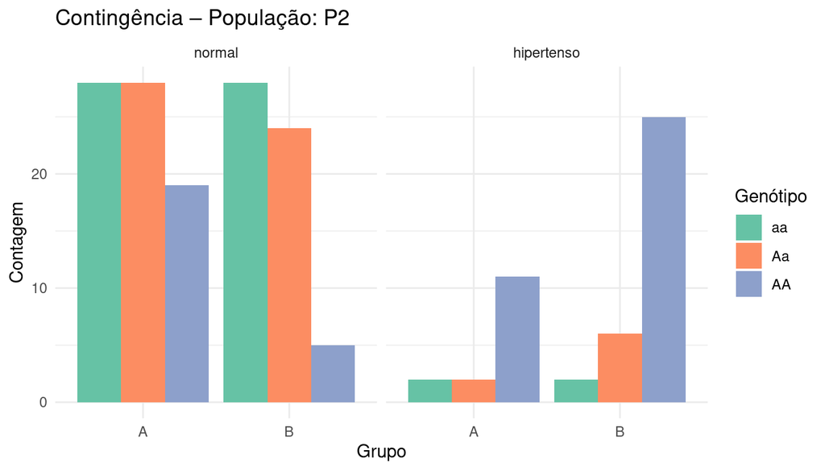

```
##
## Modelo logístico – fator categórico:
##
## Call:
## glm(formula = Ybin ~ Grupo * Genotipo, family = binomial(link = "logit"),
##     data = dat)
##
## Coefficients:
##                     Estimate Std. Error z value Pr(>|z|)
## (Intercept)       -2.639e+00  7.319e-01  -3.606 0.000311 ***
## GrupoB            -2.387e-14  1.035e+00   0.000 1.000000
## GenotipoAa        -1.622e-14  1.035e+00   0.000 1.000000
## GenotipoAA         2.093e+00  8.242e-01   2.539 0.011119 *
## GrupoB:GenotipoAa  1.253e+00  1.347e+00   0.930 0.352491
## GrupoB:GenotipoAA  2.156e+00  1.206e+00   1.787 0.073875 .
## ---
## Signif. codes:  0 '***' 0.001 '**' 0.01 '*' 0.05 '.' 0.1 ' ' 1
##
## (Dispersion parameter for binomial family taken to be 1)
##
##     Null deviance: 208.77  on 179  degrees of freedom
## Residual deviance: 140.57  on 174  degrees of freedom
## AIC: 152.57
##
## Number of Fisher Scoring iterations: 5
##
##
## OR estimados:
##       (Intercept)            GrupoB        GenotipoAa        GenotipoAA GrupoB:GenotipoAa GrupoB:GenotipoAA
##             0.071             1.000             1.000             8.105             3.500             8.636
##
## Acurácia: 0.844
##
## Modelo logístico – genótipo quantitativo:
##
## Call:
## glm(formula = Ybin ~ Grupo * Geno_num, family = binomial(link = "logit"),
##     data = dat)
##
## Coefficients:
##                 Estimate Std. Error z value Pr(>|z|)
## (Intercept)      -3.2340     0.7409  -4.365 1.27e-05 ***
## GrupoB           -0.1561     1.0155  -0.154  0.87785
## Geno_num          1.2807     0.4492   2.851  0.00436 **
## GrupoB:Geno_num   1.1052     0.6521   1.695  0.09011 .
## ---
## Signif. codes:  0 '***' 0.001 '**' 0.01 '*' 0.05 '.' 0.1 ' ' 1
##
## (Dispersion parameter for binomial family taken to be 1)
##
##     Null deviance: 208.77  on 179  degrees of freedom
## Residual deviance: 144.15  on 176  degrees of freedom
## AIC: 152.15
##
## Number of Fisher Scoring iterations: 5
##
##
## OR estimados:
##     (Intercept)          GrupoB        Geno_num GrupoB:Geno_num
##           0.039           0.855           3.599           3.020
##
## Acurácia: 0.844
```

```r
logistica_pop(dat_P3, "P3")
```

```
##
##
## ==============================
##  POPULAÇÃO: P3
## ==============================
```

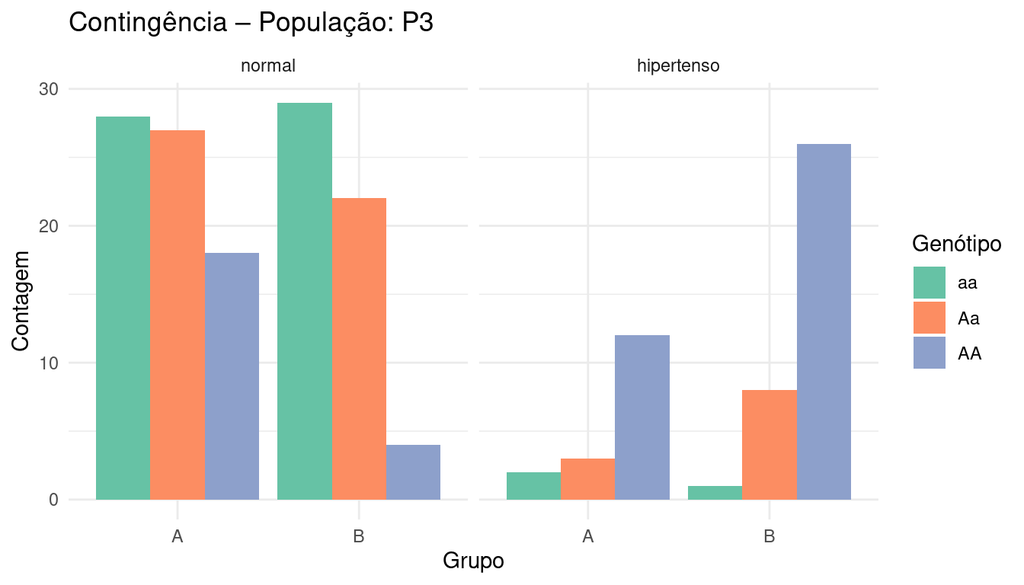

```
##
## Modelo logístico – fator categórico:
##
## Call:
## glm(formula = Ybin ~ Grupo * Genotipo, family = binomial(link = "logit"),
##     data = dat)
##
## Coefficients:
##                   Estimate Std. Error z value Pr(>|z|)
## (Intercept)        -2.6391     0.7319  -3.606 0.000311 ***
## GrupoB             -0.7282     1.2531  -0.581 0.561132
## GenotipoAa          0.4418     0.9519   0.464 0.642529
## GenotipoAA          2.2336     0.8213   2.719 0.006539 **
## GrupoB:GenotipoAa   1.9139     1.4529   1.317 0.187759
## GrupoB:GenotipoAA   3.0055     1.4133   2.127 0.033460 *
## ---
## Signif. codes:  0 '***' 0.001 '**' 0.01 '*' 0.05 '.' 0.1 ' ' 1
##
## (Dispersion parameter for binomial family taken to be 1)
##
##     Null deviance: 216.42  on 179  degrees of freedom
## Residual deviance: 141.71  on 174  degrees of freedom
## AIC: 153.71
##
## Number of Fisher Scoring iterations: 6
##
##
## OR estimados:
##       (Intercept)            GrupoB        GenotipoAa        GenotipoAA GrupoB:GenotipoAa GrupoB:GenotipoAA
##             0.071             0.483             1.556             9.333             6.779            20.196
##
## Acurácia: 0.833
##
## Modelo logístico – genótipo quantitativo:
##
## Call:
## glm(formula = Ybin ~ Grupo * Geno_num, family = binomial(link = "logit"),
##     data = dat)
##
## Coefficients:
##                 Estimate Std. Error z value Pr(>|z|)
## (Intercept)      -3.0644     0.6907  -4.437 9.13e-06 ***
## GrupoB           -0.5955     1.0150  -0.587  0.55737
## Geno_num          1.2830     0.4241   3.025  0.00248 **
## GrupoB:Geno_num   1.4481     0.6782   2.135  0.03276 *
## ---
## Signif. codes:  0 '***' 0.001 '**' 0.01 '*' 0.05 '.' 0.1 ' ' 1
##
## (Dispersion parameter for binomial family taken to be 1)
##
##     Null deviance: 216.42  on 179  degrees of freedom
## Residual deviance: 142.72  on 176  degrees of freedom
## AIC: 150.72
##
## Number of Fisher Scoring iterations: 5
##
##
## OR estimados:
##     (Intercept)          GrupoB        Geno_num GrupoB:Geno_num
##           0.047           0.551           3.608           4.255
##
## Acurácia: 0.833
```

> **Regressão Logística por população:** **P1:** assim como no teste original feito com ANOVA, temos que o efeito do `Genotipo` não é significativo, mas sim somente o efeito de `Grupo` (p < 0,001). Apesar da acurácia do teste preditivo não ter sido tão alta (76,1%), a regressão logística trouxe a mesma significância que ANOVA, levando à mesma conclusão. O mesmo resultado de significâncias foi obtido tanto com SNP considerado categórico como quando numérico.

## 3.5 Regressão Logística Combinada (3 populações)

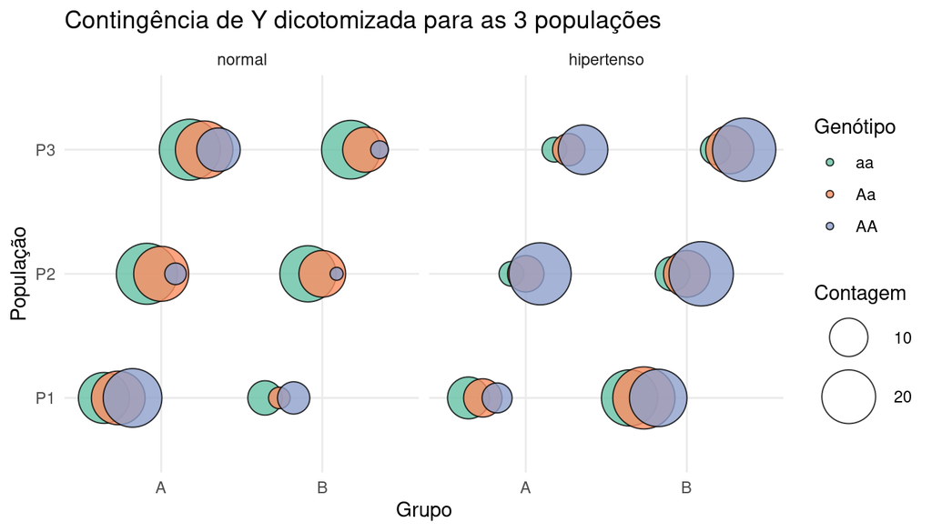

```r
# Contingência
contagem <- as.data.frame(table(dat_all$Grupo,
                                dat_all$Pop,
                                dat_all$Genotipo,
                                dat_all$Ybin))
names(contagem) <- c("Grupo", "Pop", "Genotipo", "Ybin", "Freq")
contagem$Grupo <- factor(contagem$Grupo, levels = c("A", "B"))
contagem$Pop <- factor(contagem$Pop, levels = c("P1", "P2", "P3"))
contagem$Genotipo <- factor(contagem$Genotipo, levels = c("aa", "Aa", "AA"))
contagem$Ybin <- factor(contagem$Ybin, levels = c("0", "1"))

plot <- ggplot2::ggplot(contagem,
                        ggplot2::aes(x = Grupo,
                                     y = Pop,
                                     fill = Genotipo,
                                     size = Freq)) +
  ggplot2::geom_point(position = ggplot2::position_dodge(width = 0.8),
                      shape = 21,
                      color = "black",
                      alpha = 0.8) +
  ggplot2::facet_wrap(
    ~ Ybin,
    labeller = ggplot2::labeller(
      Ybin = c("0" = "normal", "1" = "hipertenso")
    )
  ) +
  ggplot2::scale_fill_brewer(type = "qual", palette = "Set2", name = "Genótipo") +
  ggplot2::scale_size_area(max_size = 16, guide = ggplot2::guide_legend(title = "Contagem")) +
  ggplot2::labs(
    title = "Contingência de Y dicotomizada para as 3 populações",
    x = "Grupo",
    y = "População"
  ) +
  ggplot2::theme_minimal()

print(plot)
```

```r
# Efeito fixo de Pop
fitrl_all_fixo <- glm(Ybin ~ Grupo * Genotipo * Pop,
                      family=binomial(link="logit"), data=dat_all)
summary(fitrl_all_fixo)
```

```
##
## Call:
## glm(formula = Ybin ~ Grupo * Genotipo * Pop, family = binomial(link = "logit"),
##     data = dat_all)
##
## Coefficients:
##                         Estimate Std. Error z value Pr(>|z|)
## (Intercept)              -0.4055     0.3727  -1.088  0.27661
## GrupoB                    1.4171     0.5562   2.548  0.01084 *
## GenotipoAa               -0.2877     0.5375  -0.535  0.59248
## GenotipoAA               -0.9808     0.5893  -1.665  0.09601 .
## PopP2                    -1.4663     0.6537  -2.243  0.02489 *
## PopP3                    -1.4663     0.6537  -2.243  0.02489 *
## GrupoB:GenotipoAa         1.4733     0.9109   1.617  0.10578
## GrupoB:GenotipoAA         1.1588     0.8391   1.381  0.16725
## GrupoB:PopP2             -0.5569     0.8765  -0.635  0.52522
## GrupoB:PopP3             -0.9316     0.8979  -1.038  0.29948
## GenotipoAa:PopP2          1.3122     0.8580   1.529  0.12616
## GenotipoAA:PopP2          5.0499     1.0030   5.035 4.79e-07 ***
## GenotipoAa:PopP3          0.9699     0.8739   1.110  0.26706
## GenotipoAA:PopP3          3.1209     0.8783   3.553  0.00038 ***
## GrupoB:GenotipoAa:PopP2  -1.4862     1.2573  -1.182  0.23716
## GrupoB:GenotipoAA:PopP2  -0.8489     1.6019  -0.530  0.59614
## GrupoB:GenotipoAa:PopP3  -0.6357     1.2833  -0.495  0.62034
## GrupoB:GenotipoAA:PopP3   0.7265     1.3683   0.531  0.59547
## ---
## Signif. codes:  0 '***' 0.001 '**' 0.01 '*' 0.05 '.' 0.1 ' ' 1
##
## (Dispersion parameter for binomial family taken to be 1)
##
##     Null deviance: 748.60  on 539  degrees of freedom
## Residual deviance: 543.75  on 522  degrees of freedom
## AIC: 579.75
##
## Number of Fisher Scoring iterations: 5
```

```r
cat("\nOR estimados:\n")
```

```
##
## OR estimados:
```

```r
print(round(exp(coef(fitrl_all_fixo)), 3))
```

```
##             (Intercept)                  GrupoB              GenotipoAa              GenotipoAA                   PopP2                   PopP3       GrupoB:GenotipoAa
##                   0.667                   4.125                   0.750                   0.375                   0.231                   0.231                   4.364
##       GrupoB:GenotipoAA            GrupoB:PopP2            GrupoB:PopP3        GenotipoAa:PopP2        GenotipoAA:PopP2        GenotipoAa:PopP3        GenotipoAA:PopP3
##                   3.186                   0.573                   0.394                   3.714                 156.000                   2.638                  22.667
## GrupoB:GenotipoAa:PopP2 GrupoB:GenotipoAA:PopP2 GrupoB:GenotipoAa:PopP3 GrupoB:GenotipoAA:PopP3
##                   0.226                   0.428                   0.530                   2.068
```

```r
# Modelo misto logístico (Pop aleatório)
library(lme4)
fitrl_all_misto <- glmer(Ybin ~ Grupo * Genotipo * (1|Pop),
                         family=binomial(link="logit"), data=dat_all)
summary(fitrl_all_misto)
```

```
## Generalized linear mixed model fit by maximum likelihood (Laplace Approximation) ['glmerMod']
##  Family: binomial  ( logit )
## Formula: Ybin ~ Grupo * Genotipo * (1 | Pop)
##    Data: dat_all
##
##       AIC       BIC    logLik -2*log(L)  df.resid
##     640.9     670.9    -313.4     626.9       533
##
## Scaled residuals:
##      Min       1Q   Median       3Q      Max
## -3.08683 -0.74029 -0.07955  0.81553  2.07018
##
## Random effects:
##  Groups Name        Variance Std.Dev.
##  Pop    (Intercept) 0.03731  0.1932
## Number of obs: 540, groups:  Pop, 3
##
## Fixed effects:
##                   Estimate Std. Error z value Pr(>|z|)
## (Intercept)        -1.2631     0.2780  -4.544 5.52e-06 ***
## GrupoB              0.8538     0.3338   2.558   0.0105 *
## GenotipoAa          0.3544     0.3452   1.027   0.3046
## GenotipoAA          1.4882     0.3321   4.481 7.43e-06 ***
## GrupoB:GenotipoAa   0.6549     0.4635   1.413   0.1577
## GrupoB:GenotipoAA   1.0150     0.5194   1.954   0.0507 .
## ---
## Signif. codes:  0 '***' 0.001 '**' 0.01 '*' 0.05 '.' 0.1 ' ' 1
##
## Correlation of Fixed Effects:
##             (Intr) GrupoB GentpA GntpAA GrB:GA
## GrupoB      -0.698
## GenotipoAa  -0.674  0.561
## GenotipoAA  -0.703  0.584  0.564
## GrupB:GntpA  0.501 -0.719 -0.745 -0.419
## GrpB:GntpAA  0.447 -0.642 -0.361 -0.638  0.463
```

```r
confint(fitrl_all_misto)
```

```
##                         2.5 %     97.5 %
## .sig01             0.00000000  0.7400220
## (Intercept)       -1.85427796 -0.7118414
## GrupoB             0.20815405  1.5214510
## GenotipoAa        -0.31925591  1.0397236
## GenotipoAA         0.85028101  2.1561738
## GrupoB:GenotipoAa -0.25506039  1.5652368
## GrupoB:GenotipoAA  0.01118295  2.0566793
```

## 3.6 Comparação ANOVA vs. Regressão Logística

```r
library(knitr)

# ── helpers ────────────────────────────────────────────────────────────────
fmt <- function(x) ifelse(is.na(x), "—",
                   ifelse(x < 0.001, "< 0.001",
                          formatC(x, digits = 3, format = "f")))

get_pv_aov <- function(fit_aov, term) {
  s <- summary(fit_aov)[[1]]
  rownames(s) <- trimws(rownames(s))
  if (term %in% rownames(s)) s[term, "Pr(>F)"] else NA
}

get_pv_glm <- function(fit_glm, term) {
  cf <- summary(fit_glm)$coef
  if (term %in% rownames(cf)) cf[term, "Pr(>|z|)"] else NA
}

get_pv_lm <- function(fit_lm, term) {
  cf <- summary(fit_lm)$coef
  if (term %in% rownames(cf)) cf[term, "Pr(>|t|)"] else NA
}

# ── Q1 Caso 1 ──────────────────────────────────────────────────────────────
fit_lm_q1c1  <- lm(Y ~ xa + xd, data = dat1)
anova_q1c1   <- anova(fit_lm_q1c1)

pv_anova_q1_xa <- anova_q1c1["xa", "Pr(>F)"]
pv_anova_q1_xd <- anova_q1c1["xd", "Pr(>F)"]
pv_logit_q1_xa <- get_pv_glm(fitrl1_ad, "xa")
pv_logit_q1_xd <- get_pv_glm(fitrl1_ad, "xd")

# ── Q1 Caso 2 (modelos reduzidos) ──────────────────────────────────────────
anova_q1c2  <- anova(fit2_reduzido)
logit_q1c2  <- summary(fitrl2_reduzido)$coef

get_a2 <- function(term) {
  if (term %in% rownames(anova_q1c2)) anova_q1c2[term, "Pr(>F)"] else NA
}
get_l2 <- function(term) {
  if (term %in% rownames(logit_q1c2)) logit_q1c2[term, "Pr(>|z|)"] else NA
}

# ── Q2 por população (corte = 90 mmHg) ─────────────────────────────────────
make_logit_pop <- function(dat) {
  dat$Ybin <- as.factor(ifelse(dat$Y > 90, 1, 0))
  glm(Ybin ~ Grupo * Genotipo, family = binomial(link = "logit"), data = dat)
}

fit_logit_P1 <- make_logit_pop(dat_P1)
fit_logit_P2 <- make_logit_pop(dat_P2)
fit_logit_P3 <- make_logit_pop(dat_P3)

# P1
pv_aov_P1_grp  <- get_pv_aov(res_P1$fit_cat, "Grupo")
pv_aov_P1_geno <- get_pv_aov(res_P1$fit_cat, "Genotipo")
pv_aov_P1_int  <- get_pv_aov(res_P1$fit_cat, "Grupo:Genotipo")
pv_glm_P1_grp  <- get_pv_glm(fit_logit_P1, "GrupoB")
pv_glm_P1_geno <- get_pv_glm(fit_logit_P1, "GenotipoAA")
pv_glm_P1_int  <- get_pv_glm(fit_logit_P1, "GrupoB:GenotipoAA")

# P2
pv_aov_P2_grp  <- get_pv_aov(res_P2$fit_cat, "Grupo")
pv_aov_P2_geno <- get_pv_aov(res_P2$fit_cat, "Genotipo")
pv_aov_P2_int  <- get_pv_aov(res_P2$fit_cat, "Grupo:Genotipo")
pv_glm_P2_grp  <- get_pv_glm(fit_logit_P2, "GrupoB")
pv_glm_P2_geno <- get_pv_glm(fit_logit_P2, "GenotipoAA")
pv_glm_P2_int  <- get_pv_glm(fit_logit_P2, "GrupoB:GenotipoAA")

# P3
pv_aov_P3_grp  <- get_pv_aov(res_P3$fit_cat, "Grupo")
pv_aov_P3_geno <- get_pv_aov(res_P3$fit_cat, "Genotipo")
pv_aov_P3_int  <- get_pv_aov(res_P3$fit_cat, "Grupo:Genotipo")
pv_glm_P3_grp  <- get_pv_glm(fit_logit_P3, "GrupoB")
pv_glm_P3_geno <- get_pv_glm(fit_logit_P3, "GenotipoAA")
pv_glm_P3_int  <- get_pv_glm(fit_logit_P3, "GrupoB:GenotipoAA")

# ── Q2 Combinado – Pop FIXO ─────────────────────────────────────────────────
pv_aov_fix_grp  <- get_pv_aov(fit_fixo, "Grupo")
pv_aov_fix_geno <- get_pv_aov(fit_fixo, "Genotipo")
pv_aov_fix_int  <- get_pv_aov(fit_fixo, "Grupo:Genotipo")
pv_glm_fix_grp  <- get_pv_glm(fitrl_all_fixo, "GrupoB")
pv_glm_fix_geno <- get_pv_glm(fitrl_all_fixo, "GenotipoAA")
pv_glm_fix_int  <- get_pv_glm(fitrl_all_fixo, "GrupoB:GenotipoAA")

# ── Q2 Combinado – Pop ALEATÓRIO ───────────────────────────────────────────
lmer_cf  <- as.data.frame(summary(fit_misto)$coef)
glmer_cf <- as.data.frame(summary(fitrl_all_misto)$coef)
pcol_lmer  <- grep("Pr", colnames(lmer_cf),  value = TRUE)[1]
pcol_glmer <- grep("Pr", colnames(glmer_cf), value = TRUE)[1]

get_pv_mx <- function(cf, row, pcol) {
  if (row %in% rownames(cf) && !is.na(pcol)) cf[row, pcol] else NA
}

pv_lmer_grp   <- get_pv_mx(lmer_cf,  "GrupoB",           pcol_lmer)
pv_lmer_geno  <- get_pv_mx(lmer_cf,  "GenotipoAA",        pcol_lmer)
pv_lmer_int   <- get_pv_mx(lmer_cf,  "GrupoB:GenotipoAA", pcol_lmer)
pv_glmer_grp  <- get_pv_mx(glmer_cf, "GrupoB",            pcol_glmer)
pv_glmer_geno <- get_pv_mx(glmer_cf, "GenotipoAA",         pcol_glmer)
pv_glmer_int  <- get_pv_mx(glmer_cf, "GrupoB:GenotipoAA",  pcol_glmer)

# ── Montar tabela ──────────────────────────────────────────────────────────
comp <- data.frame(
  `Questão` = c(
    rep("Q1 – Caso 1", 2),
    rep("Q1 – Caso 2", 6),
    rep("Q2 – P1", 3),
    rep("Q2 – P2", 3),
    rep("Q2 – P3", 3),
    rep("Q2 – Combinado (Pop fixo)", 3),
    rep("Q2 – Combinado (Pop aleatório)", 3)
  ),
  `Efeito` = c(
    "xa (aditivo)", "xd (dominância)",
    "xa1", "xd1", "xa2", "xd2",
    "xa1:xa2 (epistasia a×a)", "xd1:xa2 (epistasia d×a)",
    "Grupo", "Genótipo (AA)", "Grupo:Genótipo (AA)",
    "Grupo", "Genótipo (AA)", "Grupo:Genótipo (AA)",
    "Grupo", "Genótipo (AA)", "Grupo:Genótipo (AA)",
    "Grupo", "Genótipo (AA)", "Grupo:Genótipo (AA)",
    "GrupoB", "GenotipoAA", "GrupoB:GenotipoAA"
  ),
  `p ANOVA / lmer` = fmt(c(
    pv_anova_q1_xa,   pv_anova_q1_xd,
    get_a2("xa1"),    get_a2("xd1"),
    get_a2("xa2"),    get_a2("xd2"),
    get_a2("xa1:xa2"), get_a2("xd1:xa2"),
    pv_aov_P1_grp, pv_aov_P1_geno, pv_aov_P1_int,
    pv_aov_P2_grp, pv_aov_P2_geno, pv_aov_P2_int,
    pv_aov_P3_grp, pv_aov_P3_geno, pv_aov_P3_int,
    pv_aov_fix_grp, pv_aov_fix_geno, pv_aov_fix_int,
    pv_lmer_grp,    pv_lmer_geno,    pv_lmer_int
  )),
  `p Logístico / glmer` = fmt(c(
    pv_logit_q1_xa,   pv_logit_q1_xd,
    get_l2("xa1"),    get_l2("xd1"),
    get_l2("xa2"),    get_l2("xd2"),
    get_l2("xa1:xa2"), get_l2("xd1:xa2"),
    pv_glm_P1_grp, pv_glm_P1_geno, pv_glm_P1_int,
    pv_glm_P2_grp, pv_glm_P2_geno, pv_glm_P2_int,
    pv_glm_P3_grp, pv_glm_P3_geno, pv_glm_P3_int,
    pv_glm_fix_grp, pv_glm_fix_geno, pv_glm_fix_int,
    pv_glmer_grp,   pv_glmer_geno,   pv_glmer_int
  )),
  check.names = FALSE
)

knitr::kable(comp,
             caption = paste("Comparação de p-valores: ANOVA/lmer vs. Regressão Logística/glmer.",
                             "Q1C1: corte Y=111; Q1C2: corte Y=105 (modelos reduzidos);",
                             "Q2 por pop: corte Y=90 mmHg; Q2 combinado: corte=mediana global."),
             align = c("l", "l", "r", "r"))
```

Comparação de p-valores: ANOVA/lmer vs. Regressão Logística/glmer. Q1C1: corte Y=111; Q1C2: corte Y=105 (modelos reduzidos); Q2 por pop: corte Y=90 mmHg; Q2 combinado: corte=mediana global.

| Questão | Efeito | p ANOVA / lmer | p Logístico / glmer |
| --- | --- | --- | --- |
| Q1 – Caso 1 | xa (aditivo) | < 0.001 | < 0.001 |
| Q1 – Caso 1 | xd (dominância) | < 0.001 | < 0.001 |
| Q1 – Caso 2 | xa1 | < 0.001 | < 0.001 |
| Q1 – Caso 2 | xd1 | < 0.001 | < 0.001 |
| Q1 – Caso 2 | xa2 | < 0.001 | 0.006 |
| Q1 – Caso 2 | xd2 | 0.001 | 0.001 |
| Q1 – Caso 2 | xa1:xa2 (epistasia a×a) | < 0.001 | 0.158 |
| Q1 – Caso 2 | xd1:xa2 (epistasia d×a) | 0.001 | 0.021 |
| Q2 – P1 | Grupo | < 0.001 | < 0.001 |
| Q2 – P1 | Genótipo (AA) | 0.761 | 0.324 |
| Q2 – P1 | Grupo:Genótipo (AA) | 0.755 | 0.424 |
| Q2 – P2 | Grupo | < 0.001 | 1.000 |
| Q2 – P2 | Genótipo (AA) | < 0.001 | 0.011 |
| Q2 – P2 | Grupo:Genótipo (AA) | 0.324 | 0.074 |
| Q2 – P3 | Grupo | < 0.001 | 0.561 |
| Q2 – P3 | Genótipo (AA) | < 0.001 | 0.007 |
| Q2 – P3 | Grupo:Genótipo (AA) | < 0.001 | 0.033 |
| Q2 – Combinado (Pop fixo) | Grupo | < 0.001 | 0.011 |
| Q2 – Combinado (Pop fixo) | Genótipo (AA) | < 0.001 | 0.096 |
| Q2 – Combinado (Pop fixo) | Grupo:Genótipo (AA) | < 0.001 | 0.167 |
| Q2 – Combinado (Pop aleatório) | GrupoB | < 0.001 | 0.011 |
| Q2 – Combinado (Pop aleatório) | GenotipoAA | < 0.001 | < 0.001 |
| Q2 – Combinado (Pop aleatório) | GrupoB:GenotipoAA | < 0.001 | 0.051 |

> **Impacto da dicotomização:** Sim, há impacto da categorização nos resultados de significância. Ao longo da questão 3, percebemos que as mudanças observadas nos resultados de significância entre os testes de ANOVA e regressão logística são principalmente consequência da mudança da natureza do estudo, uma vez que não mais estudamos o efeito das variáveis sobre o valor Y em si, mas sim a sua influência sobre a alocação dos indivíduos em condições clínicas distintas. As interpretações a cada caso diferem entre os modelos. Na ANOVA, os coeficientes representam diferenças médias na resposta quantitativa, enquanto na regressão logística representam mudanças no *log-odds* e *odds ratios* associados à probabilidade do fenótipo dicotomizado. A categorização da variável resposta reduz a quantidade de informação disponível, pois diferentes valores contínuos passam a pertencer à mesma categoria binária. Em geral, isso pode reduzir o poder estatístico da análise. Contudo, mais que uma limitação, a dicotomização é uma mudança de foco do estudo e uma ferramenta útil para responder a perguntas clínicas específicas, como a identificação de fatores de risco para uma condição. A escolha do ponto de corte é crucial e pode influenciar significativamente os resultados, sendo importante ter consciência da relevância biológica da dicotomização adotada nesse processo.

*Documento gerado com R Markdown – IBI5086/2026*